# Trabajo Final de Máster (2da parte)

Daniel Núñez Vargas

En este notebook se datallan los pasos a seguir después de contruido el score de riesgo, entre los cuales se destacan:

- Análisis Geoespacial
- Relación del score con variables socioeconómicas
- Modelado sin componente espacial
- Modelado con componente espacial
- Feature Engineering y Feature Selection
- Modelo Random Forest

Se cargan las librerías necesarias para análisis:

```python
# Librerias base
import pandas as pd
import numpy as np
import matplotlib.pyplot as plt
import seaborn as sns
import calendar
import time

# Para el análisis descriptivo inicial de contraste de asociación
from scipy.stats import chi2_contingency
from scipy.stats import f_oneway
from sklearn.metrics import mean_squared_error, r2_score, confusion_matrix, ConfusionMatrixDisplay, roc_curve, auc, classification_report
from imblearn.over_sampling import SMOTE
from imblearn.pipeline import Pipeline as ImbPipeline

# Librerias que permiten trabajar con datos geoespaciales
import geopandas as gpd
from libpysal import weights
import esda
import spreg
from splot import esda as esdaplot
from splot.esda import plot_moran

# Librería para hacer la tramificación, agrupación y transformación WOE
from optbinning import Scorecard, BinningProcess, OptimalBinning
from optbinning.scorecard import plot_auc_roc, plot_cap, plot_ks, ScorecardMonitoring

# Librerías para el modelo Machine Learning
from sklearn.model_selection import train_test_split
from sklearn.preprocessing import OneHotEncoder, StandardScaler
from sklearn.compose import ColumnTransformer
from sklearn.pipeline import Pipeline
from sklearn.ensemble import RandomForestClassifier
from sklearn.impute import SimpleImputer
from sklearn.model_selection import GridSearchCV, StratifiedKFold

from sklearn.ensemble import RandomForestClassifier
from sklearn.model_selection import cross_val_score, cross_validate, StratifiedKFold
from sklearn.metrics import make_scorer, recall_score, precision_score, classification_report
import numpy as np

from Funciones import * # Script donde se han incluido variedad de funciones personalizadas
```

Versiones de los paquetes necesarios:

```python
# import importlib.metadata as meta

# packages = [
#     "pandas", "numpy", "matplotlib", "seaborn", "scipy",
#     "geopandas", "contextily", "shapely", "libpysal", "esda",
#     "spreg", "splot", "optbinning", "jenkspy", "scikit-learn",
#     "imbalanced-learn", "holidays", "tqdm"
# ]

# for pkg in packages:
#     try:
#         print(pkg, meta.version(pkg))
#     except:
#         print(pkg, "NO INSTALADO")
```

```
pandas 2.3.0
numpy 1.26.4
matplotlib 3.10.3
seaborn 0.13.2
scipy 1.16.0
geopandas 1.1.1
contextily 1.6.2
shapely 2.1.1
libpysal 4.13.0
esda 2.7.1
spreg 1.8.3
splot 1.1.7
optbinning 0.20.1
jenkspy 0.4.1
scikit-learn 1.4.2
imbalanced-learn 0.12.3
holidays 0.78
tqdm 4.66.4
```

## Carga de información

Se utiliza como input las bases generadas en el primer notebook:

```python
# Carga de los datos
df_train_raw = gpd.read_file('../Input/ModelingDatasets/Train/df_train_with_score.shp')
# Se cambian los nombres que se perdieron al guardar el archivo en formato .shp utilizando una función personalizada
df_train = cleanDataframe2(df_train_raw)
df_train.head(3)
```

|  | dc_dist | psa | date | hour | crime_description | time_of_day | day_of_week | week_of_year | month | season | ... | mean_income | total_households | household_25k_or_less | household_25k_to_50k | household_50k_to_150k | household_150k_or_more | GiniIndex | risk_score | risk_level | geometry |
| --- | --- | --- | --- | --- | --- | --- | --- | --- | --- | --- | --- | --- | --- | --- | --- | --- | --- | --- | --- | --- | --- |
| 0 | 16 | 1 | 2023-12-31 | 19 | Thefts | Afternoon | Sunday | 52 | December | winter | ... | 59711.0 | 19948 | 35.8 | 22.5 | 32.9 | 8.7 | 0.5465 | 0.385733 | Low | POLYGON ((-75.21367 39.96003, -75.21204 39.959... |
| 1 | 14 | 1 | 2023-12-31 | 19 | Theft from Vehicle | Afternoon | Sunday | 52 | December | winter | ... | 65880.0 | 12823 | 28.3 | 20.5 | 45.4 | 5.6 | 0.4680 | 0.403961 | Low | POLYGON ((-75.17676 40.0502, -75.17515 40.0518... |
| 2 | 25 | 1 | 2023-12-31 | 19 | Other Assaults | Afternoon | Sunday | 52 | December | winter | ... | 51112.0 | 20557 | 39.7 | 26.8 | 29.9 | 3.6 | 0.5170 | 0.528764 | High | POLYGON ((-75.17036 40.00841, -75.16974 40.008... |

3 rows × 33 columns

```python
# Informacion general de los datos de entrenamiento
df_train.info()
```

```
<class 'geopandas.geodataframe.GeoDataFrame'>
RangeIndex: 159762 entries, 0 to 159761
Data columns (total 33 columns):
 #   Column                  Non-Null Count   Dtype
---  ------                  --------------   -----
 0   dc_dist                 159762 non-null  int64
 1   psa                     159711 non-null  object
 2   date                    159762 non-null  datetime64[ms]
 3   hour                    159762 non-null  int32
 4   crime_description       159762 non-null  object
 5   time_of_day             159762 non-null  object
 6   day_of_week             159762 non-null  object
 7   week_of_year            159762 non-null  int64
 8   month                   159762 non-null  object
 9   season                  159762 non-null  object
```

[output cut: 25 more lines]

# Análisis Geoespacial

Al realizar un análisis espacial, se estudiarían las áreas postales como unidades completas, lo que implica una pérdida de granularidad considerable: la base de datos se reduce de más de 150,000 registros a únicamente 53, que corresponden al número total de zonas postales en Filadelfia. No obstante, este enfoque presenta ventajas significativas, ya que al contar con áreas geográficas claramente delimitadas es posible realizar análisis de vecindario y examinar las relaciones espaciales que existen entre las diferentes zonas.

```python
# Se hace agrupamiento por código postal pero también por momento del día (para añadir una capa más de granularidad)
aggregate_df_train_raw = df_train.groupby(['ZCTA', 'time_of_day']).agg({
    'geometry': 'first',
    'population' : 'first',
    'white_race':'first',
    'black_race':'first',
    'latino_race':'first',
    'asian_race':'first',
    'mean_income': 'first',
    'median_income' :'first',
    'total_households': 'first',
    'household_25k_or_less': 'first',
    'household_25k_to_50k': 'first',
    'household_50k_to_150k':'first',
    'household_150k_or_more': 'first',
    'GiniIndex': 'first',
    'risk_score': 'mean',
}).reset_index()

# Se remueven NAs, es decir, aquellas áreas postales en donde para un momento del día no presentaron ningún crimen
aggregate_df_train = aggregate_df_train_raw.dropna().reset_index()

# Asegurar que sigue siendo GeoDataFrame
aggregate_df_train = gpd.GeoDataFrame(aggregate_df_train, geometry='geometry')
# Resumen
aggregate_df_train.head(3)
```

|  | index | ZCTA | time_of_day | geometry | population | white_race | black_race | latino_race | asian_race | mean_income | median_income | total_households | household_25k_or_less | household_25k_to_50k | household_50k_to_150k | household_150k_or_more | GiniIndex | risk_score |
| --- | --- | --- | --- | --- | --- | --- | --- | --- | --- | --- | --- | --- | --- | --- | --- | --- | --- | --- |
| 0 | 0 | 19004 | Night | POLYGON ((-75.24583 40.02155, -75.24562 40.023... | 10668 | 8284 | 529 | 448 | 998 | 217722.0 | 143781.0 | 4216 | 11.3 | 5.4 | 37.4 | 45.8 | 0.5115 | 0.056829 |
| 1 | 1 | 19012 | Night | POLYGON ((-75.12187 40.05327, -75.12144 40.053... | 6699 | 2792 | 2413 | 602 | 738 | 144838.0 | 117614.0 | 2237 | 5.4 | 10.6 | 46.1 | 37.8 | 0.4036 | 0.163235 |
| 2 | 2 | 19027 | Afternoon | POLYGON ((-75.15366 40.07214, -75.15332 40.072... | 19170 | 8927 | 7207 | 1092 | 1231 | 136486.0 | 105190.0 | 8417 | 13.0 | 11.9 | 42.2 | 32.8 | 0.4608 | 0.036326 |

## Variables socioeconómicas

Otra ventaja que ofrece este enfoque es que el Censo de los Estados Unidos ofrece estadísticas a nivel de área postal, lo que permite comparar el score de riesgo creado con estas variables. A continuación se muestra un ejemplo en donde en el mapa de la izquierda se muestra la distribución por score de riesgo en las áreas postales de Filadeldia y en la de la derecha el Índice de Gini:

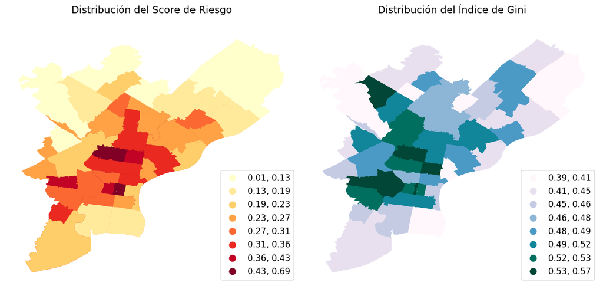

```python
# Crear una figura con subplots lado a lado
fig, axes = plt.subplots(1, 2, figsize=(12, 6))

# Mapa 1: Risk Score
map1 = aggregate_df_train.plot(column='risk_score',
                              scheme='quantiles',
                              k=8,
                              cmap='YlOrRd',
                              legend=True,
                              ax=axes[0],
                              legend_kwds={'loc': 'lower right', 'fontsize':'12'})
axes[0].set_axis_off()
axes[0].set_title('Distribución del Score de Riesgo', fontsize=14, pad=20)

# Mapa 2: Gini Index
map2 = aggregate_df_train.plot(column='GiniIndex',
                              scheme='quantiles',
                              k=8,
                              cmap='PuBuGn',
                              legend=True,
                              ax=axes[1],
                              legend_kwds={'loc': 'lower right', 'fontsize':'12'})
axes[1].set_axis_off()
axes[1].set_title('Distribución del Índice de Gini', fontsize=14, pad=20)

# Ajustar el espacio entre subplots
plt.tight_layout()

# Mostrar la figura
plt.show()
```

Los mapas muestran un patrón espacial consistente: las zonas centrales concentran tanto los valores más altos del risk score como del índice de Gini, mientras que hacia la periferia predominan niveles más bajos en ambas variables. Esta coincidencia sugiere una relación positiva entre desigualdad socioeconómica y riesgo de crimen, lo que indica que los barrios con mayores niveles de desigualdad tienden también a presentar mayor exposición a la violencia y conductas delictivas. También lo podemos hacer para el ingreso medio:

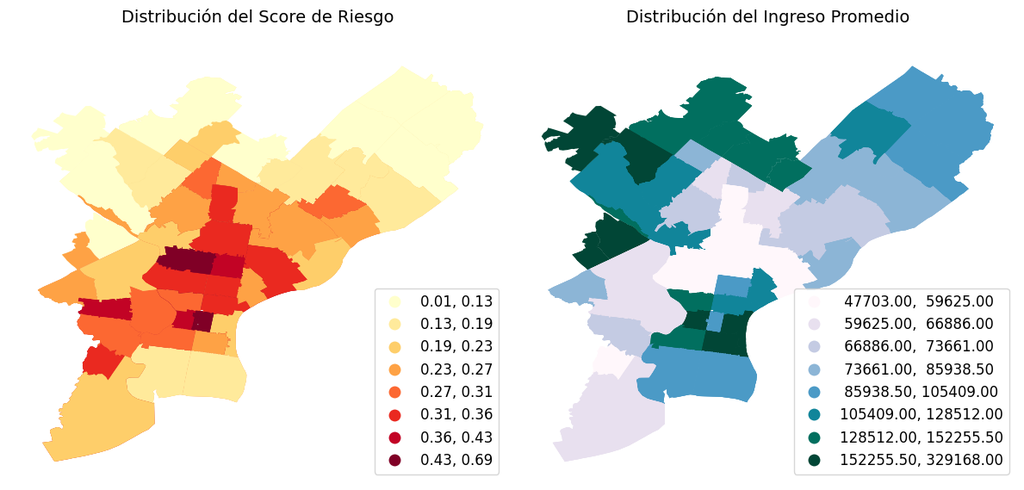

```python
# Crear una figura con subplots lado a lado
fig, axes = plt.subplots(1, 2, figsize=(12, 6))

# Mapa 1: Risk Score
map1 = aggregate_df_train.plot(column='risk_score',
                              scheme='quantiles',
                              k=8,
                              cmap='YlOrRd',
                              legend=True,
                              ax=axes[0],
                              legend_kwds={'loc': 'lower right', 'fontsize':'12'})
axes[0].set_axis_off()
axes[0].set_title('Distribución del Score de Riesgo', fontsize=14, pad=20)

# Mapa 2: Gini Index
map2 = aggregate_df_train.plot(column='mean_income',
                              scheme='quantiles',
                              k=8,
                              cmap='PuBuGn',
                              legend=True,
                              ax=axes[1],
                              legend_kwds={'loc': 'lower right', 'fontsize':'12'})
axes[1].set_axis_off()
axes[1].set_title('Distribución del Ingreso Promedio', fontsize=14, pad=20)

# Ajustar el espacio entre subplots
plt.tight_layout()

# Mostrar la figura
plt.show()
```

Hay un patrón similar, en donde las áreas blancas en el mapa de la derecha representan las zonas con los niveles de ingreso promedio más bajas, que a la vez coinciden en su mayoría con la zona central de Filadelfia, misma que se identifica como de las más peligrosas en el gráfico de la izquierda. De manera análoga, las zonas verde oscuro ubicada al norte del centro, corresponde a zonas con score de riesgos muy bajos. Haciendo lo mismo ahora con variable que cuantifica el porcentaje de hogares que presentan ingresos inferiores a los $USD \, 25 000$ anuales.

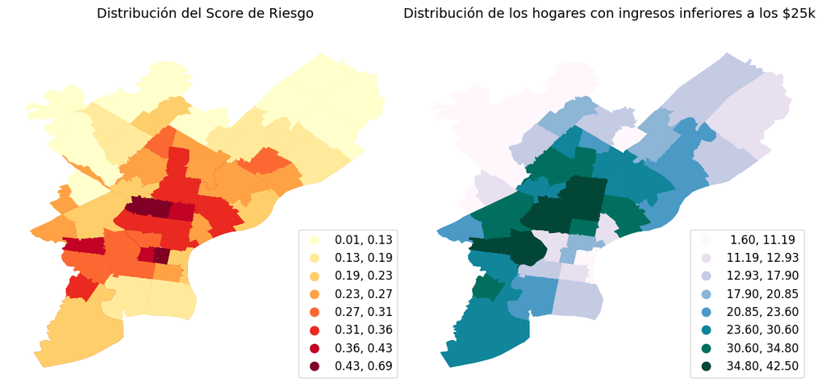

```python
# Crear una figura con subplots lado a lado
fig, axes = plt.subplots(1, 2, figsize=(12, 6))

# Mapa 1: Risk Score
map1 = aggregate_df_train.plot(column='risk_score',
                              scheme='quantiles',
                              k=8,
                              cmap='YlOrRd',
                              legend=True,
                              ax=axes[0],
                              legend_kwds={'loc': 'lower right', 'fontsize':'12'})
axes[0].set_axis_off()
axes[0].set_title('Distribución del Score de Riesgo', fontsize=14, pad=20)

# Mapa 2: Gini Index
map2 = aggregate_df_train.plot(column='household_25k_or_less',
                              scheme='quantiles',
                              k=8,
                              cmap='PuBuGn',
                              legend=True,
                              ax=axes[1],
                              legend_kwds={'loc': 'lower right', 'fontsize':'12'})
axes[1].set_axis_off()
axes[1].set_title('Distribución de los hogares con ingresos inferiores a los $25k ', fontsize=14, pad=20)

# Ajustar el espacio entre subplots
plt.tight_layout()

# Mostrar la figura
plt.show()
```

Es un análisis totalmente análogo; las zonas con mayores porcentajes de hogares con ingresos menores a los $USD \, 25 000$ están precisamente ubicadas en las zonas identificadas como de mayor peligro por el score de riesgo.

# Matriz de pesos Espaciales

Esto nos lleva al siguiente punto el cual es un análisis de una zona respecto a sus vecindades. Para ello primero se construye una matriz de pesos espaciales con contiguedad Reina, pero, ¿qué significa esto?

Su nombre viene de la funcionalidad de la reina en el ajedrez, en donde dicha pieza puede moverse en todas las direcciones (horizontal, vertical y diagonal). Este tipo de contigüedad considera que dos unidades espaciales son vecinas si comparten:

- Un borde común (contigüidad lateral)
- Un vértice común (contigüidad diagonal)

Es decir, una zona será considerada vecina de otro si comparten ya sea un borde o incluso un vértice.

```python
# Se crea la matriz
wq = weights.contiguity.Queen.from_dataframe(aggregate_df_train)
# Se normalizzan las filas
wq.transform = 'r'
```

Algunos datos generales de la matriz creada:

```python
print("Cantidad de observaciones espaciales:",  wq.n)
print("Cantidad de islas (zonas sin vecinos) :",  wq.islands)
```

```
Cantidad de observaciones espaciales: 150
Cantidad de islas (zonas sin vecinos) : []
```

Ahora se procede a realizar una representación visual sobre los vecinos de cada zona, mediante un gráfico de conexiones. Es una herramienta muy útil para identificar con facilidad los vecinos de cada zona:

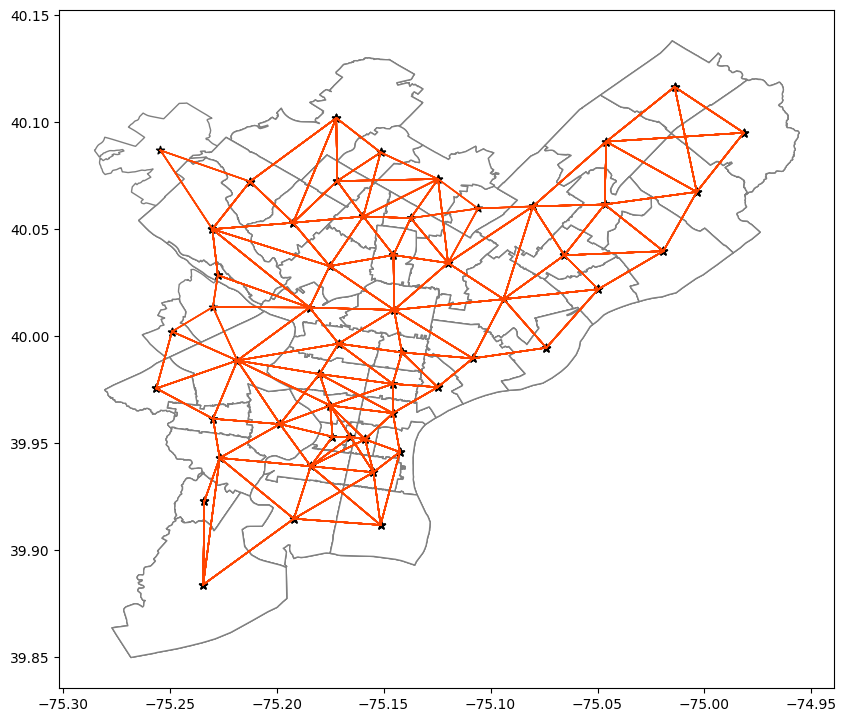

```python
# Plot graph connections
ax = aggregate_df_train.plot(
        edgecolor="grey", facecolor="w",
        figsize=(10,10)
    )

wq.plot(
    aggregate_df_train,
    edge_kws=dict(linewidth=1, color="orangered"),
    node_kws=dict(marker="*"),
    ax=ax
)

plt.show()
```

## Retardo Espacial

Una vez identificados los vecinos de cada zona, aporta mucho valor agregado calcular el retardo espacial, pero primero vale preguntarse ¿Qué se entiende por retardo?

En series temporales, el retardo (lag) se refiere a valores de una variable en períodos anteriores. Por ejemplo, usar el precio de ayer para predecir el precio de hoy, o analizar cómo las ventas de hace 3 meses afectan las ventas actuales. En análisis geoespacial, el retardo espacial se refiere a valores de una variable en ubicaciones vecinas. Por ejemplo, cómo el precio de viviendas en una zona influye en los precios de las zonas adyacentes.

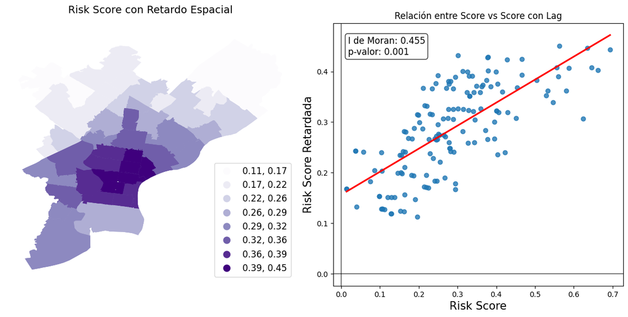

```python
# Creación de variables con retardo espacial
aggregate_df_train["risk_score_lag"] = weights.spatial_lag.lag_spatial(
    wq, aggregate_df_train["risk_score"]
)

# Crear una figura con subplots lado a lado
fig, axes = plt.subplots(1, 2, figsize=(12, 6))

# Mapa: Risk Score Retardada
map1 = aggregate_df_train.plot(column='risk_score_lag',
                              scheme='quantiles',
                              k=8,
                              cmap='Purples',
                              legend=True,
                              ax=axes[0],
                              legend_kwds={'loc': 'lower right', 'fontsize':'12'})
axes[0].set_axis_off()
axes[0].set_title('Risk Score con Retardo Espacial', fontsize=14, pad=20)

# Diagrama de Moran con estadísticas
sns.regplot(
    x="risk_score",
    y="risk_score_lag",
    ci=None,
    data=aggregate_df_train,
    line_kws={"color": "r"},
    ax=axes[1]
)
axes[1].axvline(0, c="k", alpha=0.5)
axes[1].axhline(0, c="k", alpha=0.5)

# Calcular la I de Moran
moran = esda.moran.Moran(aggregate_df_train["risk_score"], wq)

# Añadir las estadísticas dentro del gráfico
axes[1].text(0.05, 0.95, f"I de Moran: {moran.I:.3f}\np-valor: {moran.p_sim:.3f}",
            transform=axes[1].transAxes, fontsize=12, verticalalignment='top',
            bbox=dict(boxstyle="round,pad=0.3", facecolor="white", alpha=0.8))
axes[1].set_xlabel('Risk Score', fontsize=15)
axes[1].set_ylabel('Risk Score Retardada', fontsize=15)
axes[1].set_title('Relación entre Score vs Score con Lag')
plt.tight_layout()
plt.show()
```

Los resultados presentados en la figura revelan una fuerte evidencia de autocorrelación espacial positiva en el score risk desarrollado para la ciudad de Filadelfia, en donde, desde un punto de vista urbano, esto tiene sentido porque los factores de riesgo (socioeconómicos, demográficos, infraestructura) no se distribuyen de manera aleatoria en el espacio.

El mapa del lado izquierdo muestra la distribución espacial del risk score con retardo espacial, donde se observa un claro patrón de clustering, con las zonas de mayor riesgo concentradas principalmente en el área central y sur de la ciudad, mientras que las áreas periféricas tienden a presentar valores más bajos.

Por otro lado, el diagrama de dispersión confirma una relación lineal positiva entre el risk score y su respectivo retardo. Más allá de eso, se confirma que esta relación es estadísticamente significativa con una I de Moran considerada moderada-fuerte y un $p-value$ de 0.001. Esto lo que demuestra es que las zonas con altos valores de riesgo tienden a estar rodeadas por otras zonas de alto riesgo, y de manera viceversa para las zonas de bajo riesgo.

## Correlación Local

La I de Moran calculada previamente refleja la autocorrelación espacial a nivel global, lo que confirma su existencia en el conjunto de áreas postales. Sin embargo, esto no implica que todas ellas presenten el mismo comportamiento. Por ello, resulta necesario complementar el análisis con la I de Moran local, que permite identificar en qué áreas específicas existe dependencia espacial respecto a sus vecinas.

```python
#Correlación Espacial Local
lisa = esda.moran.Moran_Local(aggregate_df_train["risk_score"], wq, seed=42)
```

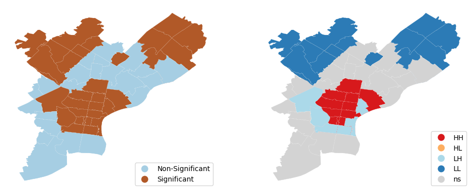

```python
# Set up figure and axes
f, axs = plt.subplots(nrows=1, ncols=2, figsize=(12, 6))
# Make the axes accessible with single indexing
axs = axs.flatten()

# Subplot 1 #
# Significance map
# Grab third axis of local statistics
ax = axs[0]
#
# Find out significant observations
labels = pd.Series(
    1 * (lisa.p_sim < 0.05),  # Assign 1 if significant, 0 otherwise
    index=aggregate_df_train.index  # Use the index in the original data
    # Recode 1 to "Significant and 0 to "Non-significant"
).map({1: "Significant", 0: "Non-Significant"})
# Assign labels to `db` on the fly
aggregate_df_train.assign(
    cl=labels
    # Plot choropleth of (non-)significant areas
).plot(
    column="cl",
    categorical=True,
    k=2,
    cmap="Paired",
    linewidth=0.1,
    edgecolor="white",
    legend=True,
    ax=ax,
    legend_kwds={'loc': 'lower right', 'fontsize':'10'}
)


# Subplot 4 #
# Cluster map
# Grab second axis of local statistics
ax = axs[1]
# Plot Quandrant colors In this case, we use a 5% significance
# level to select polygons as part of statistically significant
# clusters
esdaplot.lisa_cluster(lisa, aggregate_df_train, p=0.05, ax=ax, legend_kwds={'loc': 'lower right', 'fontsize':'10'})

# Figure styling #
# Set title to each subplot
for i, ax in enumerate(axs.flatten()):
    ax.set_axis_off()
    # ax.set_title(
    #     [
    #         "Significancia Estadística por Área Postal",
    #         "Cluster de Moran",
    #     ][i],
    #     y=0,
    # )
# Tight layout to minimise in-betwee white space
# f.tight_layout()

# Display the figure
plt.show()
```

En el panel izquierdo se muestran en color marrón las zonas con asociación espacial significativa, mientras que en azul claro aparecen aquellas sin evidencia estadística relevante. El panel derecho detalla la magnitud y dirección de dicha asociación, distinguiendo clústeres de altos rodeados de altos (HH), bajos rodeados de bajos (LL) y configuraciones mixtas (HL y LH). Las áreas sin significancia se representan en gris.

Los resultados son consistentes con lo mostrado en gráficos anteriores, donde se observa el mismo patrón: una mayor concentración de criminalidad en el centro y sur de la ciudad, con una disminución progresiva hacia la periferia. Se procede agregar como variables adicionales las observacione recién halladas al conjunto de datos original, ya que tener mapeado cuáles zonas son las que presentan dependencia espacial será de utilidad en el futuro.

```python
# Se asigna el valor del p value
aggregate_df_train["p-sim"] = lisa.p_sim
# Utilizando el p-value se crea un vector Booleana para determinar si es significante o no
sig = 1 * (lisa.p_sim < 0.05)
# Se asigna este vector como una columna en el dataframe original
aggregate_df_train["sig"] = sig

# Se hace un proceso parecido pero esta vez con los labels que identifican la magnitud de la asociación
spots = lisa.q * sig
spots_labels = {
    0: "Non-Significant",
    1: "HH",
    2: "LH",
    3: "LL",
    4: "HL",
}
# Se añade la columna al dataframe original
aggregate_df_train["labels"] = pd.Series(
    spots,
    index=aggregate_df_train.index
).map(spots_labels)
# Se muestra el conteo para cada label
aggregate_df_train["labels"].value_counts()
```

```
labels
Non-Significant    60
HH                 41
LL                 36
LH                 10
HL                  3
Name: count, dtype: int64
```

Se procede a realizar un merge entre todos los insights extraido del analisis espacial con la base de entrenamiento incial:

```python
# Se une la información agregada del análisis espacial a la base de datos original
df_train_with_lag = df_train.merge(
    right=aggregate_df_train[['ZCTA', 'time_of_day', 'risk_score_lag', 'sig', 'labels']],
    on=['ZCTA', 'time_of_day'],
    how='left'
)
df_train_with_lag.head(3)
```

|  | dc_dist | psa | date | hour | crime_description | time_of_day | day_of_week | week_of_year | month | season | ... | household_25k_to_50k | household_50k_to_150k | household_150k_or_more | GiniIndex | risk_score | risk_level | geometry | risk_score_lag | sig | labels |
| --- | --- | --- | --- | --- | --- | --- | --- | --- | --- | --- | --- | --- | --- | --- | --- | --- | --- | --- | --- | --- | --- |
| 0 | 16 | 1 | 2023-12-31 | 19 | Thefts | Afternoon | Sunday | 52 | December | winter | ... | 22.5 | 32.9 | 8.7 | 0.5465 | 0.385733 | Low | POLYGON ((-75.21367 39.96003, -75.21204 39.959... | 0.370328 | 1.0 | HH |
| 1 | 14 | 1 | 2023-12-31 | 19 | Theft from Vehicle | Afternoon | Sunday | 52 | December | winter | ... | 20.5 | 45.4 | 5.6 | 0.4680 | 0.403961 | Low | POLYGON ((-75.17676 40.0502, -75.17515 40.0518... | 0.235866 | 1.0 | HL |
| 2 | 25 | 1 | 2023-12-31 | 19 | Other Assaults | Afternoon | Sunday | 52 | December | winter | ... | 26.8 | 29.9 | 3.6 | 0.5170 | 0.528764 | High | POLYGON ((-75.17036 40.00841, -75.16974 40.008... | 0.352109 | 1.0 | HH |

3 rows × 36 columns

# Modelado

En esta sección se implementarán dos estrategias de modelado complementarias: un primer enfoque no espacial utilizando técnicas tradicionales, y un segundo enfoque que incorpora componentes espaciales. Para el modelado espacial es fundamental utilizar la base de datos agregada por zona postal, dado que los modelos espaciales requieren unidades geográficas claramente definidas para establecer relaciones de vecindad. Esta agregación representa un desafío metodológico significativo debido a la considerable reducción en el tamaño muestral (de más de 150,000 registros individuales a 53 zonas postales).

A pesar de esta limitación en términos de granularidad, el análisis espacial ofrece perspectivas valiosas sobre patrones geográficos y efectos de vecindario que no pueden capturarse mediante enfoques tradicionales, justificando la exploración de ambas metodologías para obtener una comprensión integral del fenómeno estudiado.

```python
# Dado
train = aggregate_df_train.copy()
```

## Modelo sin componente espacial

Primero se tendrá un acercamiento mediante un modelo que no considere ningún componente espacial y para ello se programará una regresión lineal simple en donde se utilizará para efectos del ejemplo la variable socioeconómica del Índice de Gini.

```python
#Regresión MCO
m1 = spreg.OLS(
    # variable dependiente
    train[["risk_score"]].values,
    # variable independiente
    train[["GiniIndex"]].values,
    # nombre de variable dependiente
    name_y="risk_score",
    # nombre de variable independiente
    name_x=["GiniIndex"]
)

print(m1.summary)
```

```
REGRESSION RESULTS
------------------

SUMMARY OF OUTPUT: ORDINARY LEAST SQUARES
-----------------------------------------
Data set            :     unknown
Weights matrix      :        None
Dependent Variable  :  risk_score                Number of Observations:         150
Mean dependent var  :      0.2848                Number of Variables   :           2
S.D. dependent var  :      0.1411                Degrees of Freedom    :         148
R-squared           :      0.2698
Adjusted R-squared  :      0.2649
Sum squared residual:     2.16729                F-statistic           :     54.6979
Sigma-square        :       0.015                Prob(F-statistic)     :   9.672e-12
S.E. of regression  :       0.121                Log likelihood        :     104.946
Sigma-square ML     :       0.014                Akaike info criterion :    -205.892
S.E of regression ML:      0.1202                Schwarz criterion     :    -199.871

------------------------------------------------------------------------------------
            Variable     Coefficient       Std.Error     t-Statistic     Probability
------------------------------------------------------------------------------------
            CONSTANT        -0.46217         0.10148        -4.55450         0.00001
           GiniIndex         1.55962         0.21088         7.39580         0.00000
------------------------------------------------------------------------------------

REGRESSION DIAGNOSTICS
MULTICOLLINEARITY CONDITION NUMBER          20.492

TEST ON NORMALITY OF ERRORS
TEST                             DF        VALUE           PROB
Jarque-Bera                       2          0.544           0.7619

DIAGNOSTICS FOR HETEROSKEDASTICITY
RANDOM COEFFICIENTS
TEST                             DF        VALUE           PROB
Breusch-Pagan test                1         16.859           0.0000
Koenker-Bassett test              1         16.135           0.0001
================================ END OF REPORT =====================================
```

El modelo presenta un R-cuadrado de 0.2698, lo que significa que el Índice de Gini explica aproximadamente el 27% de la variabilidad en el risk_score. Los diagnósticos revelan violaciones importantes de los supuestos del modelo. La prueba de Breusch-Pagan detecta heterocedasticidad significativa (p < 0.001), lo que indica que la varianza de los errores no es constante. Esto se puede visualizar en el siguiente gráfico:

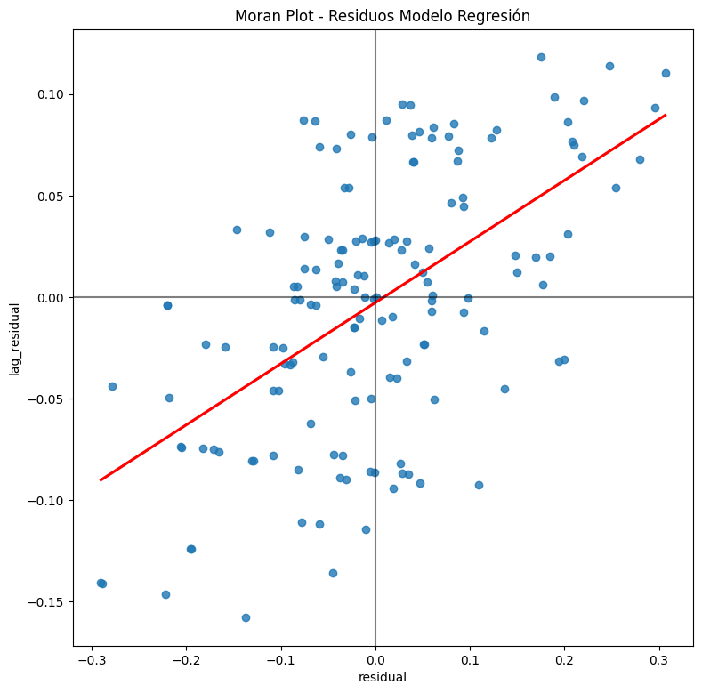

```python
# Create column with residual values from m1
train["residual"] = m1.u
train["lag_residual"] = weights.spatial_lag.lag_spatial(wq, m1.u)

f, ax = plt.subplots(1, figsize=(9, 9))
sns.regplot(
    x="residual",
    y="lag_residual",
    ci=None,
    data=train,
    line_kws={"color": "r"},
)
ax.axvline(0, c="k", alpha=0.5)
ax.axhline(0, c="k", alpha=0.5)
ax.set_title("Moran Plot - Residuos Modelo Regresión")
plt.show()
```

Hay un claro patrón en la forma en la que los residuos se distribuyen, lo cual no es lo ideal en un modelo de regresión simple. Visto esto en una proyección en el mapa:

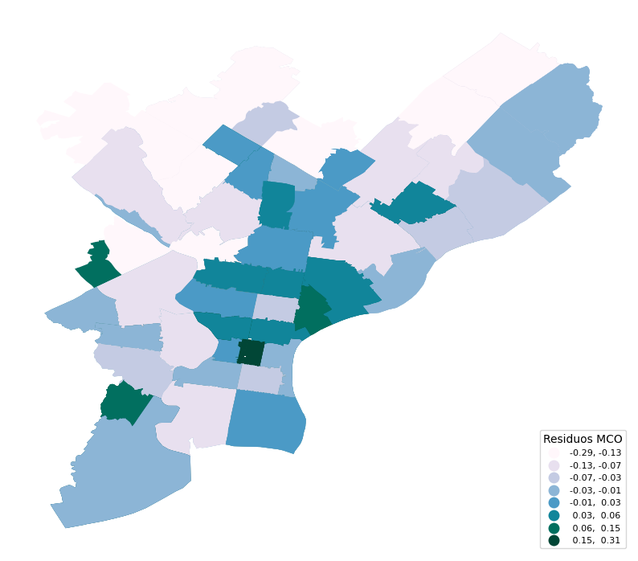

```python
# representación de los residuos
map=train.plot(column='residual',
         scheme='quantiles',
         k=8, cmap='PuBuGn',
         legend=True,
         figsize=(10,10),
         legend_kwds={'loc': 'lower right', 'fontsize':'8', 'title':'Residuos MCO'}
)
map.set_axis_off()
```

Donde en efecto vuelve a quedar en evidencia una vez más que los residuos no se están distribuyendo de manera aleatoria, hay un claro patrón.

## Modelo Espacial

Las limitantes anteriormente descritas se intenterán mejorar mediante un modelo de regresión espacial utlizando la misma covariable, la diferencia es que al ser un modelo que considera el componente geográfico, una parámetro extra que utiliza es la matriz de pesos, con la cual calcula el score de riesgo retardado.

```python
# Concatenar con tus features
X = train[["GiniIndex"]].astype(float).values
y = train[["risk_score"]].values

# (Modelo autoregresivo espacial - estimado por MC2E)
mLag = spreg.GM_Lag(
    # variable dependiente
    y=y,
    # variable independiente
    x=X,
    # Matriz de pesos
    w= wq,
    robust='white',
    # Numero de retardos a considerar para cada zona
    w_lags=3,
    #diagnósitico de correlación espacial
    spat_diag=True,
    # nombre de variable dependiente
    name_y="risk_score",
    # nombre de variable independiente
    name_x=["GiniIndex"],
    # nombre del tipo de matriz
    name_w=" Contiguidad Reina",
    name_ds=" Índice de Criminalidad en Filadelfia"

)
# , 'Afternoon', 'Night'
print(mLag.summary)
```

```
REGRESSION RESULTS
------------------

SUMMARY OF OUTPUT: SPATIAL TWO STAGE LEAST SQUARES
--------------------------------------------------
Data set            : Índice de Criminalidad en Filadelfia
Weights matrix      : Contiguidad Reina
Dependent Variable  :  risk_score                Number of Observations:         150
Mean dependent var  :      0.2848                Number of Variables   :           3
S.D. dependent var  :      0.1411                Degrees of Freedom    :         147
Pseudo R-squared    :      0.5620
Spatial Pseudo R-squared:  0.3848

White Standard Errors
------------------------------------------------------------------------------------
            Variable     Coefficient       Std.Error     z-Statistic     Probability
------------------------------------------------------------------------------------
            CONSTANT        -0.34027         0.07660        -4.44191         0.00001
           GiniIndex         0.76810         0.16869         4.55343         0.00001
        W_risk_score         0.89956         0.09467         9.50226         0.00000
------------------------------------------------------------------------------------
Instrumented: W_risk_score
Instruments: W2_GiniIndex, W3_GiniIndex, W_GiniIndex

DIAGNOSTICS FOR SPATIAL DEPENDENCE
TEST                              DF         VALUE           PROB
Anselin-Kelejian Test             1          0.352           0.5528

SPATIAL LAG MODEL IMPACTS
Impacts computed using the 'simple' method.
            Variable         Direct        Indirect          Total
           GiniIndex         0.7681          6.8795          7.6476
================================ END OF REPORT =====================================
```

- El modelo espacial muestra un pseudo R-cuadrado de 0.5620, representando una mejora notable respecto al 27% del modelo MCO tradicional. El pseudo R-cuadrado espacial de 0.3848 confirma que la incorporación de la estructura espacial añade valor explicativo significativo.
- La variable de retardo espacial (W_risk_score) presenta un coeficiente de 0.8996 altamente significativo (p < 0.001), indicando que el riesgo en áreas vecinas es un predictor muy fuerte del riesgo local.
- La prueba de Anselin-Kelejian no detecta dependencia espacial residual (p = 0.553), confirmando que el modelo captura adecuadamente la estructura espacial de los datos.

Ahora, analizando la distribución de los residuos:

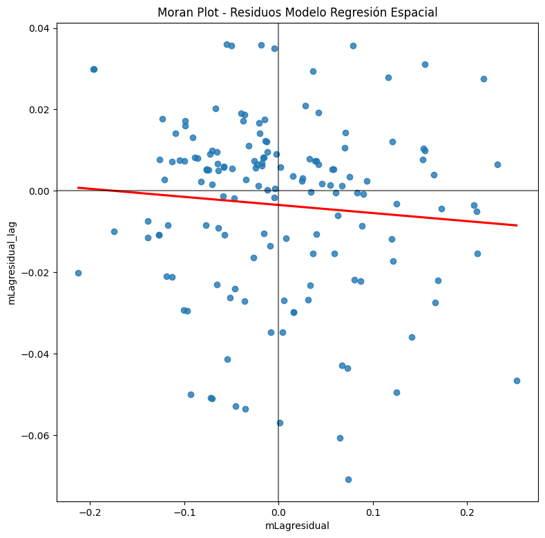

```python
# Create column with residual values from m1
train["mLagresidual"] = mLag.u
train["mLagresidual_lag"] = weights.spatial_lag.lag_spatial(wq, mLag.u)

f, ax = plt.subplots(1, figsize=(9, 9))
sns.regplot(
    x="mLagresidual",
    y="mLagresidual_lag",
    ci=None,
    data=train,
    line_kws={"color": "r"},
)
ax.axvline(0, c="k", alpha=0.5)
ax.axhline(0, c="k", alpha=0.5)
ax.set_title("Moran Plot - Residuos Modelo Regresión Espacial")
plt.show()
```

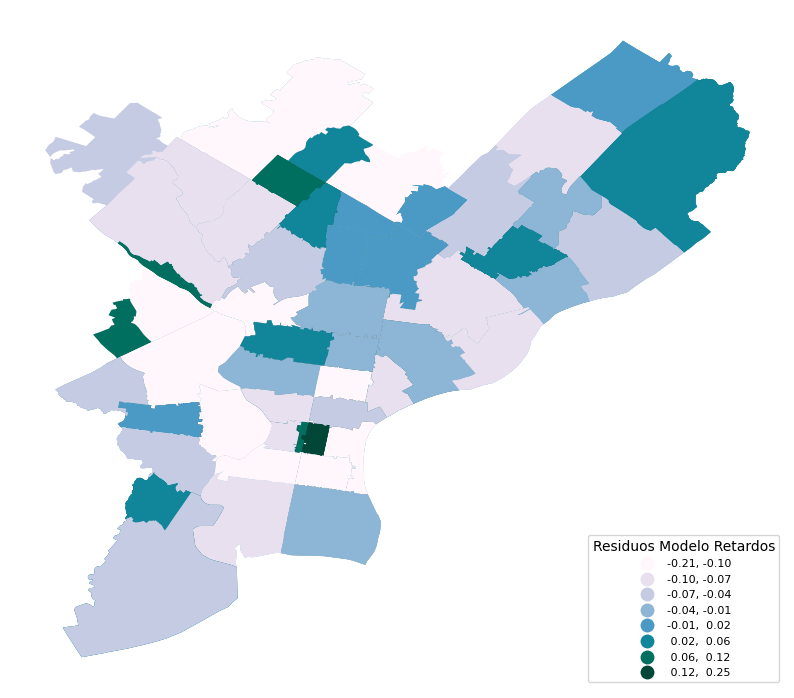

```python
# representación de los residuos Modelo Retardado
map=train.plot(column='mLagresidual',
         scheme='quantiles',
         k=8, cmap='PuBuGn',
         legend=True,
         figsize=(10,10),
         legend_kwds={'loc': 'lower right', 'fontsize':'8', 'title':'Residuos Modelo Retardos'}
)
map.set_axis_off()
```

### Predicciones

Se procede a realizar las predicciones en el conjunto de test.

```python
df_test = cleanDataframe2(gpd.read_file('../Input/ModelingDatasets/Test/df_test_with_score.shp'))
df_test = df_test[(df_test['date'] >= '2025-01-01')]
```

Importante mencionar que para efectos de este modelo como tal, se están evaluando las áreas de código postal como un todo, así que se debe homologar nuestra base de test a la misma forma en la que se entrenó nuestro modelo inicial, la cual es agrupando por código de ZCTA y momento del día.

```python
# Se hace agrupamiento
aggregate_df_test_raw = df_test.groupby(['ZCTA', 'time_of_day']).agg({
    'geometry': 'first',
    'population' : 'first',
    'white_race':'first',
    'black_race':'first',
    'latino_race':'first',
    'asian_race':'first',
    'mean_income': 'first',
    'median_income' :'first',
    'total_households': 'first',
    'household_25k_or_less': 'first',
    'household_25k_to_50k': 'first',
    'household_50k_to_150k':'first',
    'household_150k_or_more': 'first',
    'GiniIndex': 'first',
    'risk_score': 'mean',
}).reset_index()

# Se remueven NAs
aggregate_df_test = aggregate_df_test_raw.dropna().reset_index()

# Asegurar que sigue siendo GeoDataFrame
aggregate_df_test = gpd.GeoDataFrame(aggregate_df_test, geometry='geometry')

test = aggregate_df_test.copy()
```

Se procede a crear la matriz pesos espaciales para el conjunto de test:

```python
# Crear matriz de pesos espaciales de contigüidad reina para validación
wq_test = weights.Queen.from_dataframe(test)
# Normalizar
wq_test.transform = 'r'
```

La librería que se está utilizando para el modelado espacial no tiene una función de 'predict' como tal, así que se debe de resolver el sistema de ecuaciones:

\begin{align} y &= \rho W y + X \beta + \varepsilon \\ (I - \rho W) y &= X \beta \\ \hat{y} &= (I - \rho W)^{-1} X \beta \end{align}

Donde,

$y$ = variable independiente

$X$ = matriz de covariables

$\beta$ = coeficientes de regresión

$\rho$ = parámetro de dependencia espacial

$W$ = matriz de pesos espaciales

$\varepsilon$ = error

```python
# Concatenar con tus features
X_val = test[["GiniIndex"]].astype(float).values
y_val = test[["risk_score"]].values

betas = np.array(mLag.betas).flatten()
intercept = betas[0]
coefs = betas[1:-1]   # todas las covariables excepto rho
rho = betas[-1]

# Construcción de Xβ con todas las variables de una vez
Xbeta = intercept + X_val.dot(coefs)

W_test, ids = wq_test.full()
n = W_test.shape[0]

I = np.eye(n)
M = I - rho * W_test
Xbeta_vec = Xbeta.reshape(-1, 1)

try:
    y_val_pred = np.linalg.solve(M, Xbeta_vec).flatten()
except np.linalg.LinAlgError:
    print("Advertencia: (I - rho W) es singular; usando pseudo-inversa")
    y_val_pred = np.linalg.pinv(M).dot(Xbeta_vec).flatten()
```

Realizando las predicciones llegamos a los siguientes resultados:

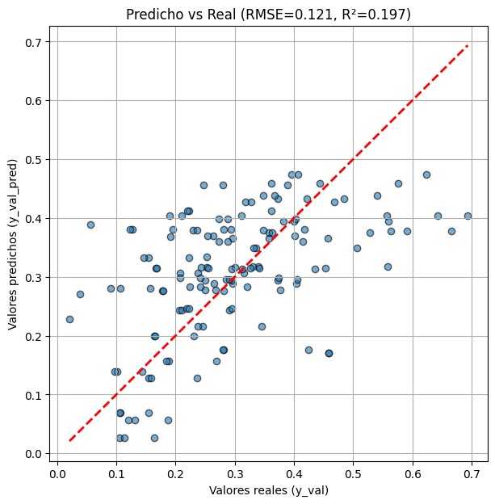

```python
# 1) Valores reales y predichos
y_true = y_val.flatten()
y_pred = y_val_pred

# 2) Métricas
rmse = np.sqrt(mean_squared_error(y_true, y_pred))
r2 = r2_score(y_true, y_pred)

# 3) Scatter plot Predicho vs Real
plt.figure(figsize=(7,7))
plt.scatter(y_true, y_pred, alpha=0.6, edgecolor="k")
plt.plot([y_true.min(), y_true.max()], [y_true.min(), y_true.max()], 'r--', lw=2)
plt.xlabel("Valores reales (y_val)")
plt.ylabel("Valores predichos (y_val_pred)")
plt.title(f"Predicho vs Real (RMSE={rmse:.3f}, R²={r2:.3f})")
plt.grid(True)
plt.show()
```

Los resultados obtenidos revelan una discrepancia significativa entre el rendimiento en entrenamiento y validación. Mientras que el modelo espacial alcanzó un pseudo R-cuadrado de 0.56 en entrenamiento, la caída a 0.19 en validación representa una pérdida bastante considerable en capacidad explicativa.

La agregación a nivel de zona postal crea un escenario particularmente problemático para modelos espaciales. Con solo 150 observaciones y la complejidad inherente de capturar relaciones espaciales complejas, el modelo está memorizando patrones específicos del conjunto de entrenamiento que no se generalizan efectivamente a nuevos datos.

Es necesario retornar a enfoques no espaciales utilizando la base de datos completa con métodos de machine learning que puedan capturar patrones complejos sin depender necesariamente agregaciones geográficas que comprometen la robustez estadística del modelo.

# Selección de Features para modelo ML

Si bien se adoptó un enfoque tradicional basado en modelos de clasificación de machine learning, los insights obtenidos del análisis geoespacial se incorporarán al modelo. Entre estos destacan el score con retardo espacial calculado para cada ZCTA, así como el nivel de asociación de cada área con sus zonas vecinas.

```python
# Se hace copia del train
train = df_train_with_lag.dropna().copy()
del df_train_with_lag

# Carga datos del test
df_test = cleanDataframe2(gpd.read_file('../Input/ModelingDatasets/Test/df_test_with_score.shp'))
# Se hace join con el risk score lag que se calculó con el train
test = df_test.merge(
    right=aggregate_df_train[['ZCTA', 'time_of_day', 'risk_score_lag', 'sig', 'labels']],
    on=['ZCTA', 'time_of_day'],
    how='left'
)

del df_test
```

```python
# Subdividimos la data en X_train, X_test, y_train, y_test

X_train = train.drop(['risk_score', 'risk_level'], axis = 1)
y_train = train['risk_level']
y_train = (y_train == 'High').astype(int)

X_test = test.drop(['risk_score', 'risk_level'], axis = 1)
y_test = test['risk_level']
y_test = (y_test == 'High').astype(int)
```

Se implementaron transformaciones sobre las variables poblacionales, las cuales se encontraban originalmente expresadas en valores absolutos. Para optimizar el análisis y facilitar la interpretación de los resultados, estas variables fueron convertidas a porcentajes relativos. Su estudio a profundidad se detallará más adelante.

```python
# Transformaciones de variables
train['white_population'] = (train['white_race']) / train['population']
train['non_white_population'] =  (train['black_race'] + train['latino_race'] + train['asian_race']) / train['population']

test['white_population'] = (test['white_race']) / test['population']
test['non_white_population'] =  (test['black_race'] + test['latino_race'] + test['asian_race']) / test['population']
```

## Variable Respuesta (Risk Score)

La variable objetivo (risk_level) mantiene una distribución muy similar en ambos conjuntos de datos, lo cual evidencia que el procedimiento de partición fue adecuado y que el muestreo preserva la proporción de las clases.

Esta estabilidad entre las distribuciones garantiza que el modelo será evaluado en un escenario representativo de los datos de entrenamiento, reduciendo el riesgo de sesgos derivados de un desbalance en la partición y aumentando la validez de las conclusiones que se obtengan del análisis.

```python
pd.concat([
    train['risk_level'].value_counts(normalize=True),
    test['risk_level'].value_counts(normalize=True)
], axis=1, keys=['Test', 'Train']).fillna(0)
```

[output not shown]

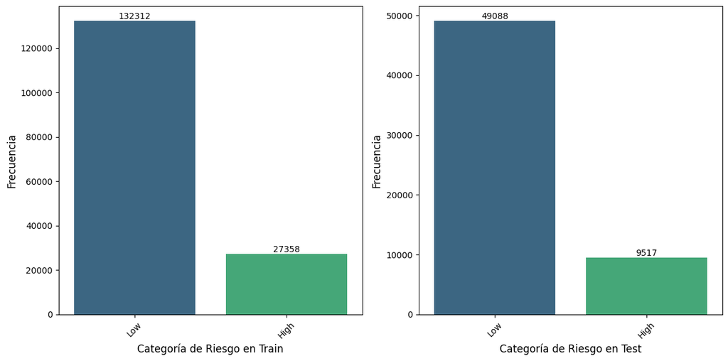

```python
fig, (ax1, ax2) = plt.subplots(1, 2, figsize=(12, 6))

sns.countplot(data=train, x='risk_level', palette='viridis',
              order=train['risk_level'].value_counts(normalize=True).index, ax=ax1)
ax1.set_xlabel('Categoría de Riesgo en Train', fontsize=12)
ax1.set_ylabel('Frecuencia', fontsize=12)
ax1.tick_params(axis='x', rotation=45)

for p in ax1.patches:
    ax1.annotate(f'{int(p.get_height())}',
                (p.get_x() + p.get_width()/2., p.get_height()),
                ha='center', va='bottom', fontsize=10)

sns.countplot(data=test, x='risk_level', palette='viridis',
              order=test['risk_level'].value_counts(normalize=True).index, ax=ax2)
ax2.set_xlabel('Categoría de Riesgo en Test', fontsize=12)
ax2.set_ylabel('Frecuencia', fontsize=12)
ax2.tick_params(axis='x', rotation=45)

for p in ax2.patches:
    ax2.annotate(f'{int(p.get_height())}',
                (p.get_x() + p.get_width()/2., p.get_height()),
                ha='center', va='bottom', fontsize=10)

plt.tight_layout()
plt.show()
```

## Variables Categóricas

Primero hacemos una breve identificación sobre cuáles son las variables categóricas y su respectiva cardinalidad.

```python
# Analizamos la cardinalidad de las variables categóricas
lista_cat = [
    'dc_dist', 'psa', 'hour', 'time_of_day',
    'day_of_week', 'week_of_year', 'month', 'season',
    'is_holiday','ZCTA', 'sig', 'labels'
]

train[lista_cat].nunique().sort_values(ascending = False)
```

```
ZCTA            53
week_of_year    52
hour            24
dc_dist         22
month           12
day_of_week      7
psa              6
labels           5
season           4
time_of_day      3
is_holiday       2
sig              2
dtype: int64
```

#### Hour

Notamos que la mayoría de crímenes sucenden durante el día, puntualmente entre 10am y las 6pm, lo cual hace sentido porque justamente es en estas horas donde hay mayor actividad poblacional. Un punto crítico se observa alrededor de las 4:00 pm, momento en el que una parte importante de la población finaliza su jornada laboral y se incrementa el flujo urbano, generando así un mayor número de potenciales víctimas.

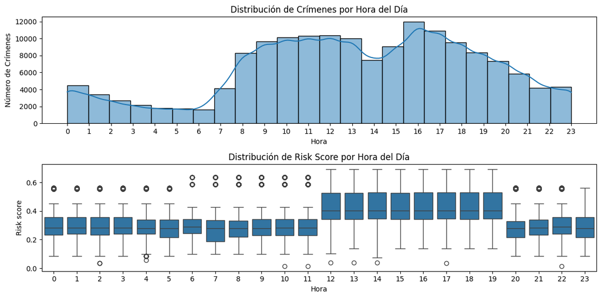

```python
fig, axes = plt.subplots(2, 1, figsize=(12, 6))

sns.histplot(data=train, x='hour', bins=24, kde=True, ax=axes[0])
axes[0].set_title('Distribución de Crímenes por Hora del Día')
axes[0].set_xlabel('Hora')
axes[0].set_ylabel('Número de Crímenes')
axes[0].set_xticks(range(0, 24))

sns.boxplot(data=train, x='hour', y='risk_score', ax=axes[1])
axes[1].set_title('Distribución de Risk Score por Hora del Día')
axes[1].set_xlabel('Hora')
axes[1].set_ylabel('Risk score')
axes[1].set_xticks(range(0, 24))

plt.tight_layout()
plt.show()
```

La V de Cramer para esta variable viene dada por:

```python
chi2_cramersv(df = train, target='risk_level', cat_vars=['hour'])
```

|  | variable | p_value | cramers_v |
| --- | --- | --- | --- |
| 0 | hour | 0.0 | 0.377759 |

#### Time of Day

Esta variable no es más que una agrupación de las horas del día. Tiene una V de Cramer casi idéntica que la variable 'hour' con la ventaja que se redujo bastante su cardinalidad por lo que es mucho más sencilla su interpretación.

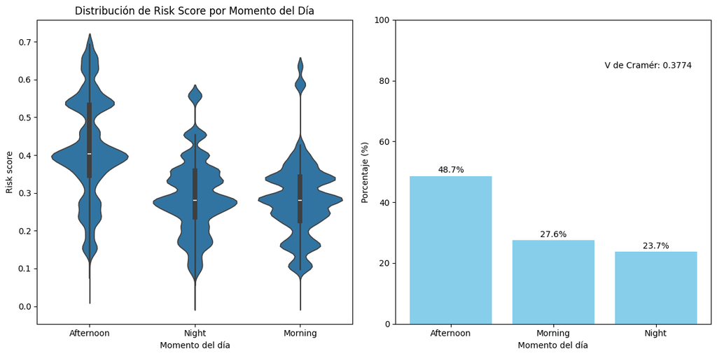

```python
fig, axes = plt.subplots(1, 2, figsize=(12, 6))

sns.violinplot(data=train, x='time_of_day', y='risk_score', ax=axes[0])
axes[0].set_title('Distribución de Risk Score por Momento del Día')
axes[0].set_xlabel('Momento del día')
axes[0].set_ylabel('Risk score')

counts = train['time_of_day'].value_counts(normalize=True) * 100
bars = axes[1].bar(counts.index, counts.values, color='skyblue')
axes[1].set_ylabel('Porcentaje (%)')
axes[1].set_xlabel('Momento del día')
axes[1].set_ylim(0, 100)

for bar in bars:
    height = bar.get_height()
    axes[1].text(bar.get_x() + bar.get_width()/2, height + 1, f'{height:.1f}%', ha='center', fontsize=10)

# Añadir texto V de Cramér
cramerV = chi2_cramersv(df=train, target='risk_level', cat_vars=['time_of_day'])
axes[1].text(1.50, 84, f"V de Cramér: {round(cramerV['cramers_v'].iloc[0], 4):.4f}", fontsize=10)

plt.tight_layout()
plt.show()
```

#### Dc_District

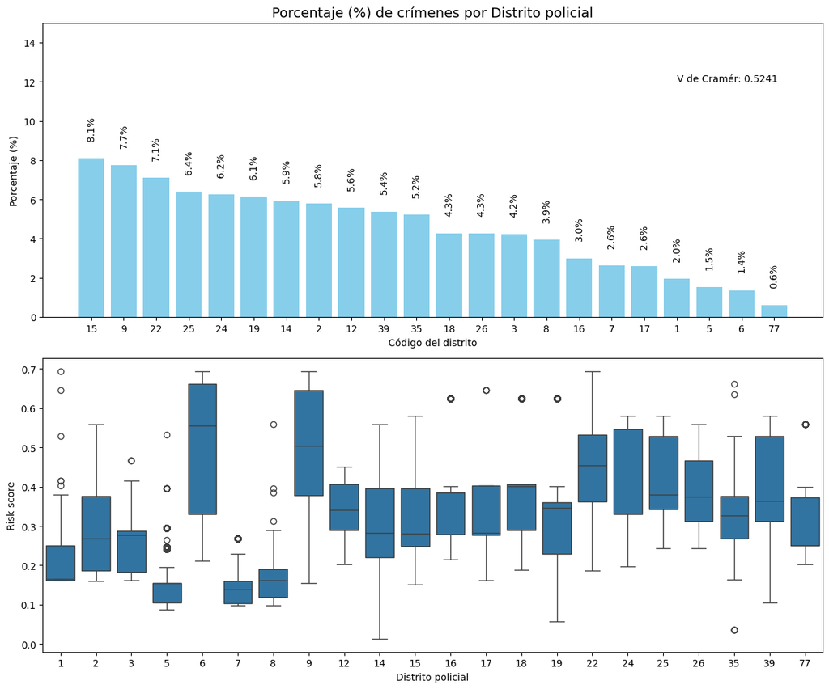

```python
# V de Cramer
cramerV = chi2_cramersv(df = train, target='risk_level', cat_vars=['dc_dist'])

# Porcentajes
counts = train['dc_dist'].value_counts(normalize=True) * 100

fig, (ax1, ax2) = plt.subplots(2, 1, figsize=(12, 10))

# Gráfico 1 - Arriba
bars = ax1.bar(counts.index.astype(str), counts.values, color='skyblue')
ax1.set_title('Porcentaje (%) de crímenes por Distrito policial', fontsize=14)
ax1.set_ylabel('Porcentaje (%)')
ax1.set_xlabel('Código del distrito')
ax1.set_ylim(0, 15)

# Etiquetas en cada barra
for bar in bars:
    height = bar.get_height()
    ax1.text(bar.get_x() + bar.get_width()/2, height + 1, f'{height:.1f}%',
             ha='center', fontsize=10, rotation=90)

# Añadir texto V de Cramér
ax1.text(len(counts)-4, 12, f"V de Cramér: {round(cramerV['cramers_v'].iloc[0], 4):.4f}", fontsize=10)

# Gráfico 2 - Abajo
sns.boxplot(data=train, x='dc_dist', y='risk_score', ax=ax2)
ax2.set_xlabel('Distrito policial')
ax2.set_ylabel('Risk score')

plt.tight_layout()
plt.show()
```

En general se nota que los distritos 6 y 9 son los que presentan los índices de riesgo más altos. Curiosamente, el 9 es el segundo con más datos y el 6 en el segundo en menos datos. Es una variable a considerar para efectos del modelado.

#### Psa

Área de Servicio Policial (Police Service Area) - subdivisión más pequeña dentro de cada distrito. Hasta cierto punto depende del distrito policial y su V de Cramer no es tan significante por lo que se descartaría para efectos del modelado.

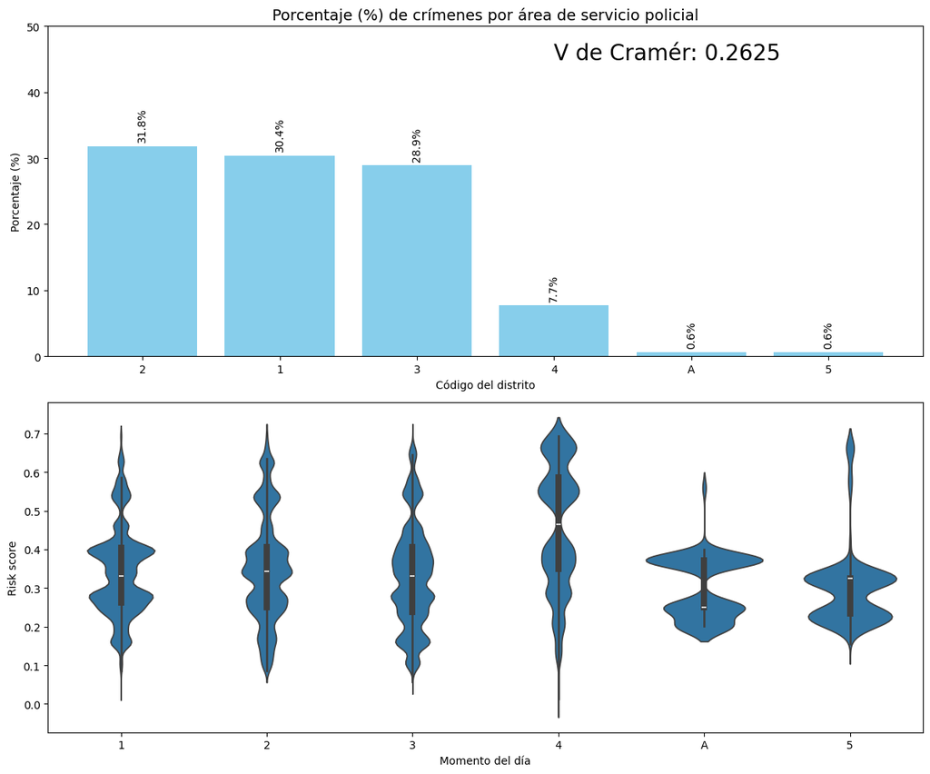

```python
# V de Cramer
cramerV = chi2_cramersv(df = train, target='risk_level', cat_vars=['psa'])

# Porcentajes
counts = train['psa'].value_counts(normalize=True) * 100

fig, (ax1, ax2) = plt.subplots(2, 1, figsize=(12, 10))

# Gráfico 1 - Arriba
bars = ax1.bar(counts.index.astype(str), counts.values, color='skyblue')
ax1.set_title('Porcentaje (%) de crímenes por área de servicio policial', fontsize=14)
ax1.set_ylabel('Porcentaje (%)')
ax1.set_xlabel('Código del distrito')
ax1.set_ylim(0, 50)

# Etiquetas en cada barra
for bar in bars:
    height = bar.get_height()
    ax1.text(bar.get_x() + bar.get_width()/2, height + 1, f'{height:.1f}%',
             ha='center', fontsize=10, rotation=90)

# Añadir texto V de Cramér
ax1.text(len(counts)-3, 45, f"V de Cramér: {round(cramerV['cramers_v'].iloc[0], 4):.4f}", fontsize=20)

# Gráfico 2 - Abajo
sns.violinplot(data=train, x='psa', y='risk_score', ax=ax2)
ax2.set_xlabel('Momento del día')
ax2.set_ylabel('Risk score')

plt.tight_layout()
plt.show()
```

#### Month

La distribución de los crímenes es muy homogénea para todos los meses por lo que a priori no será una variable que aporte valor agregado para el modelado. Su V de Cramer lo confirma.

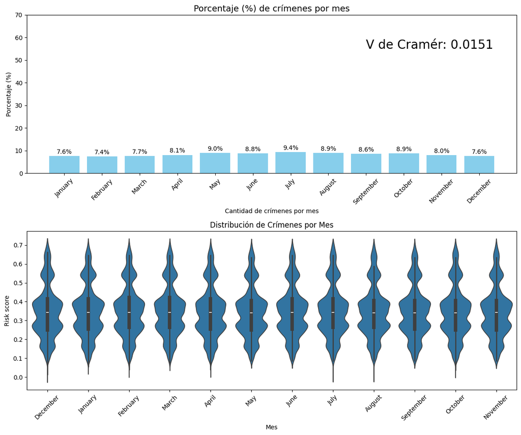

```python
# V de Cramer
cramerV = chi2_cramersv(df = train, target='risk_level', cat_vars=['month'])

order = list(calendar.month_name)[1:]

# Porcentajes
counts = train['month'].value_counts(normalize=True) * 100
counts = counts.reindex(order).dropna()

fig, (ax1, ax2) = plt.subplots(2, 1, figsize=(12, 10))

# Gráfico 1 - Arriba (Barras)
bars = ax1.bar(counts.index, counts.values, color='skyblue')
ax1.set_title('Porcentaje (%) de crímenes por mes', fontsize=14)
ax1.set_ylabel('Porcentaje (%)')
ax1.set_xlabel('Cantidad de crímenes por mes')
ax1.set_ylim(0, 70)
ax1.tick_params(axis='x', rotation=45)

# Etiquetas en cada barra
for bar in bars:
    height = bar.get_height()
    ax1.text(bar.get_x() + bar.get_width()/2, height + 1, f'{height:.1f}%',
             ha='center', fontsize=10)

# Añadir texto V de Cramér
ax1.text(len(counts)-4, 55, f"V de Cramér: {round(cramerV['cramers_v'].iloc[0], 4):.4f}", fontsize=20)

# Gráfico 2 - Abajo (Violin plot)
sns.violinplot(data=train, x='month', y='risk_score', ax=ax2)
ax2.set_title('Distribución de Crímenes por Mes')
ax2.set_xlabel('Mes')
ax2.set_ylabel('Risk score')
ax2.tick_params(axis='x', rotation=45)

plt.tight_layout()
plt.show()
```

#### Season

Caso análogo que con la variable month. Distribuciones casi que idénticas y V de Cramer insignificante.

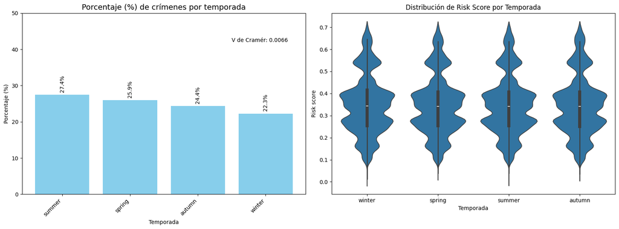

```python
fig, axes = plt.subplots(1, 2, figsize=(16, 6))  # 1 fila, 2 columnas

# ------------------------------
# Gráfico 1: porcentaje de crímenes por temporada
# ------------------------------
cramerV = chi2_cramersv(df=train, target='risk_level', cat_vars=['season'])

counts = train['season'].value_counts(normalize=True) * 100
bars = axes[0].bar(counts.index, counts.values, color='skyblue')

axes[0].set_title('Porcentaje (%) de crímenes por temporada', fontsize=14)
axes[0].set_ylabel('Porcentaje (%)')
axes[0].set_xlabel('Temporada')
axes[0].set_ylim(0, 50)
axes[0].set_xticklabels(counts.index, rotation=45, ha='right')

# Etiquetas en cada barra
for bar in bars:
    height = bar.get_height()
    axes[0].text(bar.get_x() + bar.get_width()/2, height + 1,
                 f'{height:.1f}%', ha='center', fontsize=10, rotation=90)

# Texto V de Cramér
axes[0].text(len(counts)-1.50, 42,
             f"V de Cramér: {round(cramerV['cramers_v'].iloc[0], 4):.4f}",
             fontsize=10)

# ------------------------------
# Gráfico 2: violinplot risk_score vs season
# ------------------------------
sns.violinplot(data=train, x='season', y='risk_score', ax=axes[1])
axes[1].set_title('Distribución de Risk Score por Temporada')
axes[1].set_xlabel('Temporada')
axes[1].set_ylabel('Risk score')

plt.tight_layout()
plt.show()
```

#### Week day

Pasa lo mismo que con lo analizado en las dos pasadas variables.

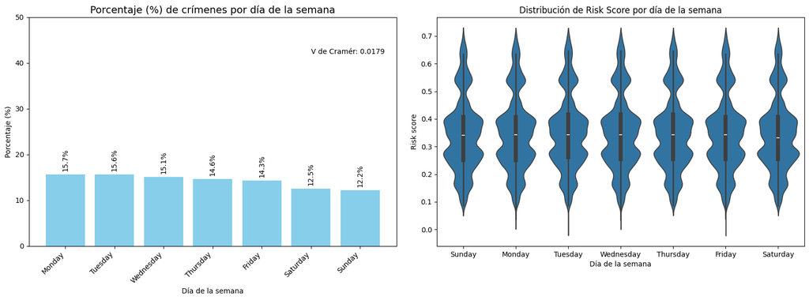

```python
fig, axes = plt.subplots(1, 2, figsize=(16, 6))  # 1 fila, 2 columnas

# ------------------------------
# Gráfico 1: porcentaje de crímenes por temporada
# ------------------------------
cramerV = chi2_cramersv(df=train, target='risk_level', cat_vars=['day_of_week'])

counts = train['day_of_week'].value_counts(normalize=True) * 100
bars = axes[0].bar(counts.index, counts.values, color='skyblue')

axes[0].set_title('Porcentaje (%) de crímenes por día de la semana', fontsize=14)
axes[0].set_ylabel('Porcentaje (%)')
axes[0].set_xlabel('Día de la semana')
axes[0].set_ylim(0, 50)
axes[0].set_xticklabels(counts.index, rotation=45, ha='right')

# Etiquetas en cada barra
for bar in bars:
    height = bar.get_height()
    axes[0].text(bar.get_x() + bar.get_width()/2, height + 1,
                 f'{height:.1f}%', ha='center', fontsize=10, rotation=90)

# Texto V de Cramér
axes[0].text(len(counts)-2, 42,
             f"V de Cramér: {round(cramerV['cramers_v'].iloc[0], 4):.4f}",
             fontsize=10)

# ------------------------------
# Gráfico 2: violinplot risk_score vs season
# ------------------------------
sns.violinplot(data=train, x='day_of_week', y='risk_score', ax=axes[1])
axes[1].set_title('Distribución de Risk Score por día de la semana')
axes[1].set_xlabel('Día de la semana')
axes[1].set_ylabel('Risk score')

plt.tight_layout()
plt.show()
```

#### Holiday

Hay muy pocas observaciones capturadas en los días de festivos y tener variables con categorías tan poco representadas podría resultar contraproducente.

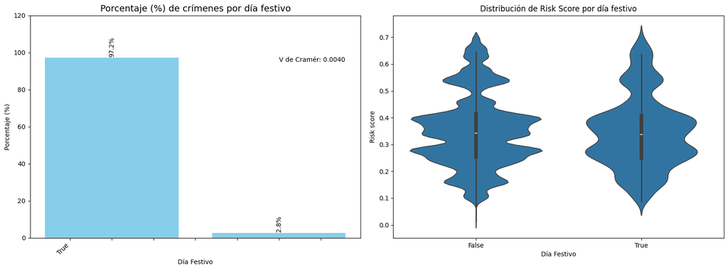

```python
fig, axes = plt.subplots(1, 2, figsize=(16, 6))  # 1 fila, 2 columnas

# ------------------------------
# Gráfico 1: porcentaje de crímenes por temporada
# ------------------------------
cramerV = chi2_cramersv(df=train, target='risk_level', cat_vars=['is_holiday'])

counts = train['is_holiday'].value_counts(normalize=True) * 100
bars = axes[0].bar(counts.index, counts.values, color='skyblue')

axes[0].set_title('Porcentaje (%) de crímenes por día festivo', fontsize=14)
axes[0].set_ylabel('Porcentaje (%)')
axes[0].set_xlabel('Día Festivo')
axes[0].set_ylim(0, 120)
axes[0].set_xticklabels(counts.index, rotation=45, ha='right')

# Etiquetas en cada barra
for bar in bars:
    height = bar.get_height()
    axes[0].text(bar.get_x() + bar.get_width()/2, height + 1,
                 f'{height:.1f}%', ha='center', fontsize=10, rotation=90)

# Texto V de Cramér
axes[0].text(len(counts)-1, 95,
             f"V de Cramér: {round(cramerV['cramers_v'].iloc[0], 4):.4f}",
             fontsize=10)

# ------------------------------
# Gráfico 2: violinplot risk_score vs season
# ------------------------------
sns.violinplot(data=train, x='is_holiday', y='risk_score', ax=axes[1])
axes[1].set_title('Distribución de Risk Score por día festivo')
axes[1].set_xlabel('Día Festivo')
axes[1].set_ylabel('Risk score')

plt.tight_layout()
plt.show()
```

#### Significancia de Autocorrelacion Local (sig)

Esta es una variable booleana obtenido del análisis geoespacial. Lo que hace es identificar si la zona en la que ocurrió el crimen tiene dependencia espacial con las zonas vecinas. En un primer análisis, sí se nota una diferencia considerable en la distribución entre las zonas que sí tenían dependencia respecto a las que no tenían. Una V de Cramer de 0.29 demuestra un nivel de asociación moderado por lo que se tomará en cuenta para efectos de iterar sobre el modelo.

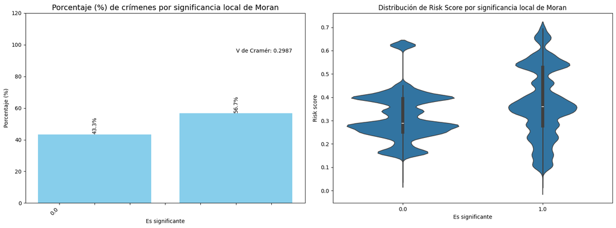

```python
fig, axes = plt.subplots(1, 2, figsize=(16, 6))  # 1 fila, 2 columnas

# ------------------------------
# Gráfico 1: porcentaje de crímenes por temporada
# ------------------------------
cramerV = chi2_cramersv(df=train, target='risk_level', cat_vars=['sig'])

counts = train['sig'].value_counts(normalize=True) * 100
bars = axes[0].bar(counts.index, counts.values, color='skyblue')

axes[0].set_title('Porcentaje (%) de crímenes por significancia local de Moran', fontsize=14)
axes[0].set_ylabel('Porcentaje (%)')
axes[0].set_xlabel('Es significante')
axes[0].set_ylim(0, 120)
axes[0].set_xticklabels(counts.index, rotation=45, ha='right')

# Etiquetas en cada barra
for bar in bars:
    height = bar.get_height()
    axes[0].text(bar.get_x() + bar.get_width()/2, height + 1,
                 f'{height:.1f}%', ha='center', fontsize=10, rotation=90)

# Texto V de Cramér
axes[0].text(len(counts)-1, 95,
             f"V de Cramér: {round(cramerV['cramers_v'].iloc[0], 4):.4f}",
             fontsize=10)

# ------------------------------
# Gráfico 2: violinplot risk_score vs season
# ------------------------------
sns.violinplot(data=train, x='sig', y='risk_score', ax=axes[1])
axes[1].set_title('Distribución de Risk Score por significancia local de Moran')
axes[1].set_xlabel('Es significante')
axes[1].set_ylabel('Risk score')

plt.tight_layout()
plt.show()
```

#### Dirección de Significancia (labels)

Esta es otra variable extraida del análisis espacial, en particular, es la que detalla la magnitud de la asociación en caso de que haya dependencia. La V de Cramer de 0.46 indica una fuerte asociación con la variable objetivo. Las distribuciones por tipo de correlación local son consistentes con su interpretación: HH (High-High) muestra zonas peligrosas rodeadas de otras zonas peligrosas con valores altos, HL y LH presentan asociaciones moderadas, LL indica zonas seguras rodeadas de áreas seguras con valores bajos, y el label non-significant refleja zonas sin correlación local significativa, con distribuciones dispersas y colas largas.

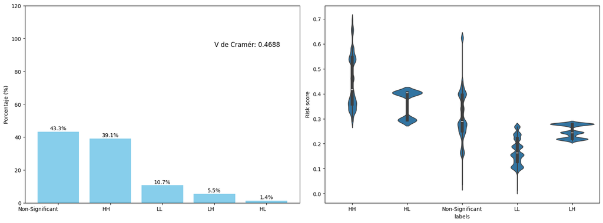

```python
fig, axes = plt.subplots(1, 2, figsize=(16, 6))  # 1 fila, 2 columnas

# ------------------------------
# Gráfico 1: porcentaje de crímenes por temporada
# ------------------------------
cramerV = chi2_cramersv(df=train, target='risk_level', cat_vars=['labels'])

counts = train['labels'].value_counts(normalize=True) * 100
bars = axes[0].bar(counts.index, counts.values, color='skyblue')

axes[0].set_ylabel('Porcentaje (%)')
axes[0].set_ylim(0, 120)
axes[0].set_xticklabels(counts.index, ha='right')

# Etiquetas en cada barra
for bar in bars:
    height = bar.get_height()
    axes[0].text(bar.get_x() + bar.get_width()/2, height + 1,
                 f'{height:.1f}%', ha='center', fontsize=10)

# Texto V de Cramér
axes[0].text(len(counts)-2, 95,
             f"V de Cramér: {round(cramerV['cramers_v'].iloc[0], 4):.4f}",
             fontsize=12)

# ------------------------------
# Gráfico 2: violinplot risk_score vs season
# ------------------------------
sns.violinplot(data=train, x='labels', y='risk_score', ax=axes[1])
axes[1].set_ylabel('Risk score')

plt.tight_layout()
plt.show()
```

Sin embargo, algunas categorías presentan baja representatividad, lo que podría inducir sobreajuste; por ello, se realizó una recategorización mediante WOE. El resultado de la recategorización fue agrupar todas las categorías excepto la HH, dado a su alto ratio de eventos de casi 40%.

```python
variable = 'labels'

optb = OptimalBinning(name=variable, dtype="categorical", solver="cp")
optb.fit(X_train[variable], y_train)

binning_table = optb.binning_table
binning_table.build()
```

|  | Bin | Count | Count (%) | Non-event | Event | Event rate | WoE | IV | JS |
| --- | --- | --- | --- | --- | --- | --- | --- | --- | --- |
| 0 | [HL, LH, LL, Non-Significant] | 97176 | 0.608605 | 94243 | 2933 | 0.030182 | 1.893697 | 1.145820 | 0.125053 |
| 1 | [HH] | 62494 | 0.391395 | 38069 | 24425 | 0.390838 | -1.132361 | 0.685158 | 0.081344 |
| 2 | Special | 0 | 0.000000 | 0 | 0 | 0.000000 | 0.0 | 0.000000 | 0.000000 |
| 3 | Missing | 0 | 0.000000 | 0 | 0 | 0.000000 | 0.0 | 0.000000 | 0.000000 |
| Totals |  | 159670 | 1.000000 | 132312 | 27358 | 0.171341 |  | 1.830978 | 0.206396 |

```python
# Transformación WOE en el conjunto train
new_variable_name = f"{variable}_WOE"
X_train[new_variable_name] = optb.transform(X_train[variable].values, metric="woe")

# Transformación WOE en el conjunto test
new_variable_name = f"{variable}_WOE"
X_test[new_variable_name] = optb.transform(X_test[variable].values, metric="woe")
```

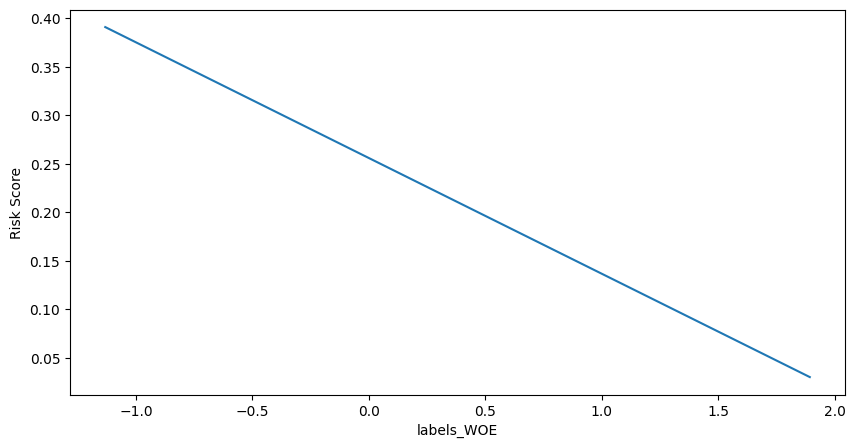

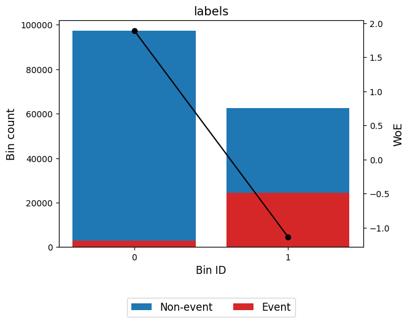

```python
# Crear el primer gráfico por separado
plt.figure(figsize=(10, 5))
plt.plot(pd.crosstab(X_train[new_variable_name].values, y_train, normalize=0).iloc[:,1])
plt.xlabel(new_variable_name)
plt.ylabel("Risk Score")
plt.show()

# Crear el segundo gráfico por separado
plt.figure(figsize=(10, 5))
binning_table.plot(metric="woe", add_special = False, add_missing = False)
```

## Variables Numéricas

### Gini Index

El Índice de Gini muestra una segmentación clara en distintos niveles de riesgo. La mayoría de las observaciones (casi la mitad del total) se concentran en el primer grupo, con valores menores a 0.49, donde la tasa de eventos es baja y refleja un perfil de menor riesgo. A medida que se avanza hacia los siguientes tramos, la proporción de eventos aumenta de forma significativa: en el intervalo de 0.49 a 0.52 la tasa de eventos se duplica frente al primer grupo, y en el rango de 0.52 a 0.54 se alcanza el nivel más alto de riesgo, con más de un tercio de las observaciones clasificadas como evento. Finalmente, el último tramo, de 0.54 en adelante, mantiene una tasa de eventos elevada aunque inferior al grupo anterior.

```python
variable = 'GiniIndex'

optb = OptimalBinning(name=variable, dtype="numerical", solver="cp")
# Una vez definido podemos pasar a estimarlo
optb.fit(X_train[variable], y_train)
optb.splits

binning_table = optb.binning_table
binning_table.build()
```

|  | Bin | Count | Count (%) | Non-event | Event | Event rate | WoE | IV | JS |
| --- | --- | --- | --- | --- | --- | --- | --- | --- | --- |
| 0 | (-inf, 0.49) | 77601 | 0.486009 | 71654 | 5947 | 0.076636 | 0.912808 | 0.295911 | 0.035756 |
| 1 | [0.49, 0.52) | 34114 | 0.213653 | 28753 | 5361 | 0.157150 | 0.103438 | 0.002209 | 0.000276 |
| 2 | [0.52, 0.54) | 27029 | 0.169280 | 16665 | 10364 | 0.383440 | -1.101181 | 0.278463 | 0.033149 |
| 3 | [0.54, inf) | 20926 | 0.131058 | 15240 | 5686 | 0.271719 | -0.590237 | 0.054688 | 0.006738 |
| 4 | Special | 0 | 0.000000 | 0 | 0 | 0.000000 | 0.0 | 0.000000 | 0.000000 |
| 5 | Missing | 0 | 0.000000 | 0 | 0 | 0.000000 | 0.0 | 0.000000 | 0.000000 |
| Totals |  | 159670 | 1.000000 | 132312 | 27358 | 0.171341 |  | 0.631271 | 0.075920 |

```python
# Transformación WOE en el conjunto train
new_variable_name = f"{variable}_WOE"
X_train[new_variable_name] = optb.transform(X_train[variable].values, metric="woe")

# Transformación WOE en el conjunto test
new_variable_name = f"{variable}_WOE"
X_test[new_variable_name] = optb.transform(X_test[variable].values, metric="woe")
```

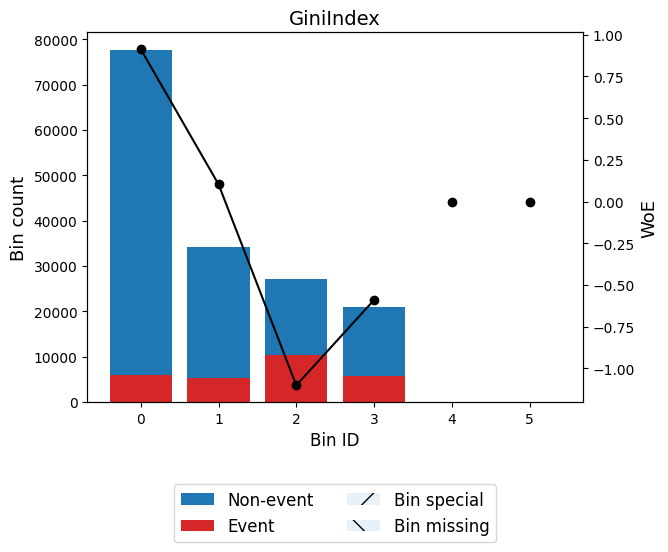

```python
# Crear el segundo gráfico por separado
plt.figure(figsize=(7, 5))
binning_table.plot(metric="woe")
```

### Mean Income

```python
variable = 'mean_income'

optb = OptimalBinning(name=variable, dtype="numerical", solver="cp")
# Una vez definido podemos pasar a estimarlo
optb.fit(X_train[variable], y_train)
optb.splits

binning_table = optb.binning_table
binning_table.build()
```

|  | Bin | Count | Count (%) | Non-event | Event | Event rate | WoE | IV | JS |
| --- | --- | --- | --- | --- | --- | --- | --- | --- | --- |
| 0 | (-inf, 53386.00) | 17575 | 0.110071 | 9461 | 8114 | 0.461679 | -1.422567 | 0.320192 | 0.036958 |
| 1 | [53386.00, 59668.00) | 22338 | 0.139901 | 14875 | 7463 | 0.334094 | -0.886429 | 0.142154 | 0.017209 |
| 2 | [59668.00, 61270.50) | 11236 | 0.070370 | 8303 | 2933 | 0.261036 | -0.535563 | 0.023808 | 0.002941 |
| 3 | [61270.50, 117040.50) | 84748 | 0.530770 | 80640 | 4108 | 0.048473 | 1.400905 | 0.643451 | 0.074439 |
| 4 | [117040.50, 153564.00) | 14812 | 0.092766 | 13354 | 1458 | 0.098434 | 0.638597 | 0.030419 | 0.003739 |
| 5 | [153564.00, inf) | 8961 | 0.056122 | 5679 | 3282 | 0.366254 | -1.027832 | 0.079188 | 0.009485 |
| 6 | Special | 0 | 0.000000 | 0 | 0 | 0.000000 | 0.0 | 0.000000 | 0.000000 |
| 7 | Missing | 0 | 0.000000 | 0 | 0 | 0.000000 | 0.0 | 0.000000 | 0.000000 |
| Totals |  | 159670 | 1.000000 | 132312 | 27358 | 0.171341 |  | 1.239213 | 0.144770 |

```python
# Transformación WOE en el conjunto train
new_variable_name = f"{variable}_WOE"
X_train[new_variable_name] = optb.transform(X_train[variable].values, metric="woe")

# Transformación WOE en el conjunto test
new_variable_name = f"{variable}_WOE"
X_test[new_variable_name] = optb.transform(X_test[variable].values, metric="woe")
```

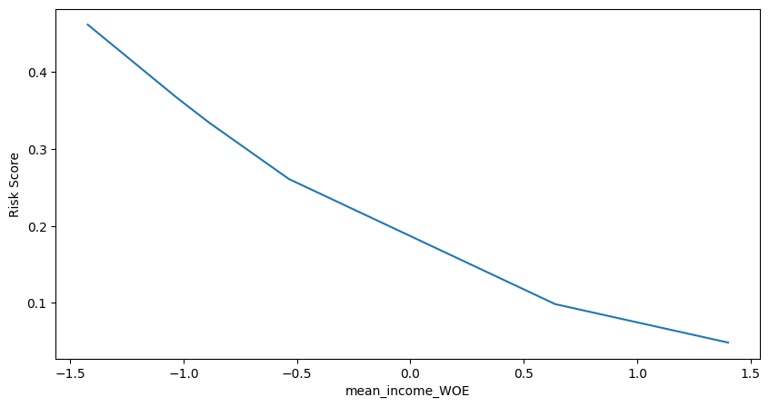

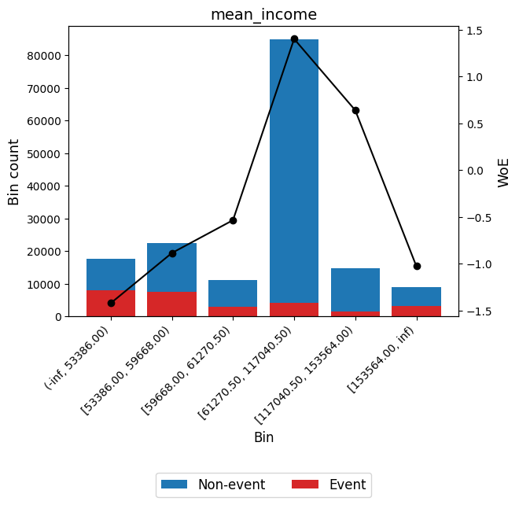

```python
# Crear el primer gráfico por separado
plt.figure(figsize=(10, 5))
plt.plot(pd.crosstab(X_train[new_variable_name].values, y_train, normalize=0).iloc[:,1])
plt.xlabel(new_variable_name)
plt.ylabel("Risk Score")
plt.show()

# Crear el segundo gráfico por separado
plt.figure(figsize=(10, 5))
binning_table.plot(metric="woe", add_special = False, add_missing = False, show_bin_labels=True )
```

### Hogares con ingresos anuales inferiores a los 25k

La variable presenta una distribución heterogénea del riesgo según los intervalos definidos. En el primer grupo, con valores menores a 20.85, se concentra cerca de un tercio de las observaciones, con una tasa de eventos de 17.8%, ligeramente superior al promedio general. El segundo tramo, entre 20.85 y 34.05, reúne la mayor proporción de casos (41.6%) y muestra la tasa de eventos más baja (6.8%), configurándose como el segmento de menor riesgo.

En cambio, los dos últimos grupos presentan tasas de evento crecientes y significativamente más altas: entre 34.05 y 37.70 la tasa alcanza 22.7%, mientras que en el tramo superior a 37.70 se observa el nivel de riesgo más elevado, con casi la mitad de las observaciones clasificadas como evento (46.2%).

```python
variable = 'household_25k_or_less'

optb, binning_table = optimal_binning(X_train, y_train, variable)
binning_table.build()
```

|  | Bin | Count | Count (%) | Non-event | Event | Event rate | WoE | IV | JS |
| --- | --- | --- | --- | --- | --- | --- | --- | --- | --- |
| 0 | (-inf, 20.85) | 49580 | 0.310515 | 40732 | 8848 | 0.178459 | -0.049331 | 0.000768 | 0.000096 |
| 1 | [20.85, 34.05) | 66457 | 0.416215 | 61968 | 4489 | 0.067547 | 1.048834 | 0.319122 | 0.038157 |
| 2 | [34.05, 37.70) | 26058 | 0.163199 | 20151 | 5907 | 0.226687 | -0.349038 | 0.022204 | 0.002762 |
| 3 | [37.70, inf) | 17575 | 0.110071 | 9461 | 8114 | 0.461679 | -1.422567 | 0.320192 | 0.036958 |
| 4 | Special | 0 | 0.000000 | 0 | 0 | 0.000000 | 0.0 | 0.000000 | 0.000000 |
| 5 | Missing | 0 | 0.000000 | 0 | 0 | 0.000000 | 0.0 | 0.000000 | 0.000000 |
| Totals |  | 159670 | 1.000000 | 132312 | 27358 | 0.171341 |  | 0.662287 | 0.077972 |

```python
# Transformación WOE en el conjunto train
new_variable_name = f"{variable}_WOE"
X_train[new_variable_name] = optb.transform(X_train[variable].values, metric="woe")

# Transformación WOE en el conjunto test
new_variable_name = f"{variable}_WOE"
X_test[new_variable_name] = optb.transform(X_test[variable].values, metric="woe")
```

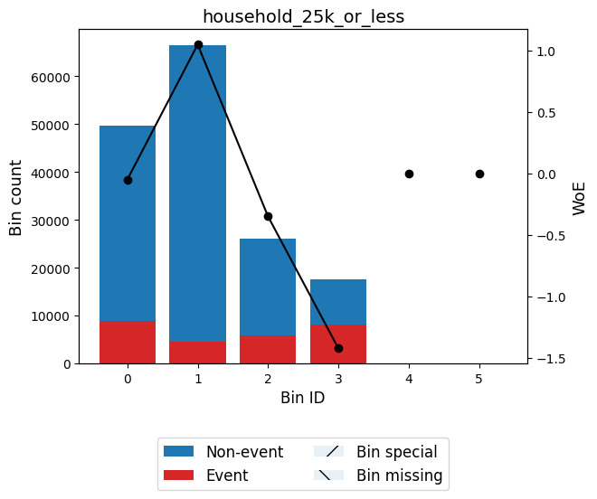

```python
# Crear el segundo gráfico por separado
plt.figure(figsize=(7, 5))
binning_table.plot(metric="woe")
```

### Hogares con ingresos superiores a los 150k

La tabla muestra cómo se distribuyen los hogares con ingresos superiores a 150k en distintos rangos, evidenciando diferencias en la proporción de eventos. Los hogares con ingresos bajos a moderados tienen una tasa de eventos más alta, mientras que los de ingresos medios presentan la tasa más baja. La variable demuestra un buen poder predictivo para diferenciar entre hogares con y sin eventos.

```python
variable = 'household_150k_or_more'

optb, binning_table = optimal_binning(X_train, y_train, variable)
binning_table.build()
```

|  | Bin | Count | Count (%) | Non-event | Event | Event rate | WoE | IV | JS |
| --- | --- | --- | --- | --- | --- | --- | --- | --- | --- |
| 0 | (-inf, 5.50) | 42243 | 0.264564 | 26707 | 15536 | 0.367777 | -1.034388 | 0.378616 | 0.045324 |
| 1 | [5.50, 8.55) | 23823 | 0.149201 | 20849 | 2974 | 0.124837 | 0.371244 | 0.018142 | 0.002255 |
| 2 | [8.55, 23.95) | 68551 | 0.429329 | 64443 | 4108 | 0.059926 | 1.176691 | 0.396423 | 0.046878 |
| 3 | [23.95, inf) | 25053 | 0.156905 | 20313 | 4740 | 0.189199 | -0.12093 | 0.002387 | 0.000298 |
| 4 | Special | 0 | 0.000000 | 0 | 0 | 0.000000 | 0.0 | 0.000000 | 0.000000 |
| 5 | Missing | 0 | 0.000000 | 0 | 0 | 0.000000 | 0.0 | 0.000000 | 0.000000 |
| Totals |  | 159670 | 1.000000 | 132312 | 27358 | 0.171341 |  | 0.795567 | 0.094755 |

```python
# Transformación WOE en el conjunto train
new_variable_name = f"{variable}_WOE"
X_train[new_variable_name] = optb.transform(X_train[variable].values, metric="woe")

# Transformación WOE en el conjunto test
new_variable_name = f"{variable}_WOE"
X_test[new_variable_name] = optb.transform(X_test[variable].values, metric="woe")
```

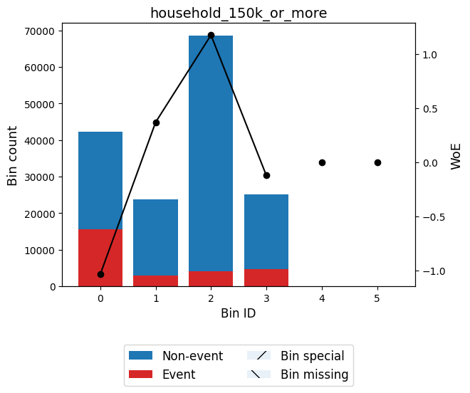

```python
# Crear el segundo gráfico por separado
plt.figure(figsize=(7, 5))
binning_table.plot(metric="woe")
```

### Población de raza blanca

La tabla muestra la distribución de la población de raza blanca en distintos rangos de la variable analizada, reflejando cómo varía la proporción de eventos entre ellos. Los rangos medios presentan la tasa de eventos más baja, mientras que los extremos tienen tasas más altas, indicando que la raza blanca tiene diferencias claras en el riesgo según el rango de la variable. En conjunto, la variable tiene un poder predictivo moderado para distinguir entre eventos y no eventos pero dada su comportamiento no lineal, se optará por descartarla de la iteración incial del modelo.

```python
variable = 'white_population'

optb, binning_table = optimal_binning(X_train, y_train, variable)
binning_table.build()
```

|  | Bin | Count | Count (%) | Non-event | Event | Event rate | WoE | IV | JS |
| --- | --- | --- | --- | --- | --- | --- | --- | --- | --- |
| 0 | (-inf, 0.04) | 10351 | 0.064827 | 7598 | 2753 | 0.265965 | -0.56096 | 0.024236 | 0.002990 |
| 1 | [0.04, 0.12) | 35979 | 0.225334 | 27685 | 8294 | 0.230523 | -0.370795 | 0.034827 | 0.004329 |
| 2 | [0.12, 0.39) | 51508 | 0.322590 | 44045 | 7463 | 0.144890 | 0.199101 | 0.011965 | 0.001493 |
| 3 | [0.39, 0.55) | 27539 | 0.172474 | 26081 | 1458 | 0.052943 | 1.307988 | 0.188120 | 0.021970 |
| 4 | [0.55, inf) | 34293 | 0.214774 | 26903 | 7390 | 0.215496 | -0.284044 | 0.018972 | 0.002364 |
| 5 | Special | 0 | 0.000000 | 0 | 0 | 0.000000 | 0.0 | 0.000000 | 0.000000 |
| 6 | Missing | 0 | 0.000000 | 0 | 0 | 0.000000 | 0.0 | 0.000000 | 0.000000 |
| Totals |  | 159670 | 1.000000 | 132312 | 27358 | 0.171341 |  | 0.278120 | 0.033146 |

```python
# Transformación WOE en el conjunto train
new_variable_name = f"{variable}_WOE"
X_train[new_variable_name] = optb.transform(X_train[variable].values, metric="woe")

# Transformación WOE en el conjunto test
new_variable_name = f"{variable}_WOE"
X_test[new_variable_name] = optb.transform(X_test[variable].values, metric="woe")
```

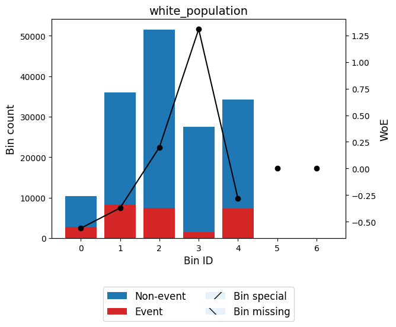

```python
# Crear el primer gráfico por separado
# plt.figure(figsize=(7, 5))
# plt.plot(pd.crosstab(X_train[new_variable_name].values, y_train, normalize=0).iloc[:,1])
# plt.xlabel(new_variable_name)
# plt.ylabel("Indice de Riesgo")
# plt.title("Índice de Riesgo vs X_WOE")
# plt.show()

# Crear el segundo gráfico por separado
plt.figure(figsize=(7, 5))
binning_table.plot(metric="woe")
```

### Población de otras etnias

La tabla refleja la distribución de la población de otras etnias según la variable analizada, mostrando diferencias en la proporción de eventos entre los rangos. La mayoría de los rangos presentan tasas de eventos moderadas a bajas, pero los extremos (especialmente el rango más alto) muestran una tasa significativamente mayor, indicando un riesgo concentrado en ciertos subgrupos. Esto se complementa con lo que pasaba para población de raza blanca, por lo que también a priori de descarta del análisis.

```python
variable = 'non_white_population'

optb, binning_table = optimal_binning(X_train, y_train, variable)
binning_table.build()
```

|  | Bin | Count | Count (%) | Non-event | Event | Event rate | WoE | IV | JS |
| --- | --- | --- | --- | --- | --- | --- | --- | --- | --- |
| 0 | (-inf, 0.27) | 14479 | 0.090681 | 11197 | 3282 | 0.226673 | -0.348961 | 0.012332 | 0.001534 |
| 1 | [0.27, 0.46) | 30470 | 0.190831 | 24904 | 5566 | 0.182671 | -0.077802 | 0.001185 | 0.000148 |
| 2 | [0.46, 0.77) | 43996 | 0.275543 | 36533 | 7463 | 0.169629 | 0.012105 | 0.000040 | 0.000005 |
| 3 | [0.77, 0.91) | 35643 | 0.223229 | 32710 | 2933 | 0.082288 | 0.835501 | 0.116979 | 0.014211 |
| 4 | [0.91, 0.97) | 23671 | 0.148250 | 20918 | 2753 | 0.116303 | 0.451765 | 0.025962 | 0.003218 |
| 5 | [0.97, inf) | 11411 | 0.071466 | 6050 | 5361 | 0.469810 | -1.455246 | 0.218625 | 0.025146 |
| 6 | Special | 0 | 0.000000 | 0 | 0 | 0.000000 | 0.0 | 0.000000 | 0.000000 |
| 7 | Missing | 0 | 0.000000 | 0 | 0 | 0.000000 | 0.0 | 0.000000 | 0.000000 |
| Totals |  | 159670 | 1.000000 | 132312 | 27358 | 0.171341 |  | 0.375122 | 0.044262 |

```python
# Transformación WOE en el conjunto train
new_variable_name = f"{variable}_WOE"
X_train[new_variable_name] = optb.transform(X_train[variable].values, metric="woe")

# Transformación WOE en el conjunto test
new_variable_name = f"{variable}_WOE"
X_test[new_variable_name] = optb.transform(X_test[variable].values, metric="woe")
```

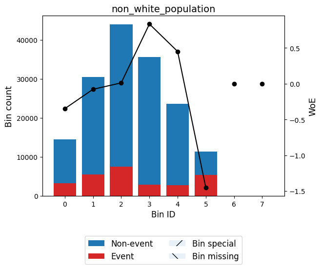

```python
# Crear el primer gráfico por separado
# plt.figure(figsize=(7, 5))
# plt.plot(pd.crosstab(X_train[new_variable_name].values, y_train, normalize=0).iloc[:,1])
# plt.xlabel(new_variable_name)
# plt.ylabel("Indice de Riesgo")
# plt.title("Índice de Riesgo vs X_WOE")
# plt.show()

# Crear el segundo gráfico por separado
plt.figure(figsize=(7, 5))
binning_table.plot(metric="woe")
```